# Network Intrusion Detection System

5/14/2020

# ABSTRACT

In this report, we developed a Network Intrusion Detection System using supervised and unsupervised data mining models for classification. The dataset used for `network_traffic.csv`. We performed exploratory data analysis and multiple factor analysis to understand the nature and patterns in intrusions. After exploration, we decided to use 4 models that work well for binary classification. We used `Logistic Regression`, `KNN`,`Decision Trees and Random Forest` and `Gradient Boosting Machine`. After building our models we evaluated the models using confusion matrix and ROC/AUC plots. In the end we present out findings and the model bank should choose for intrusion detection.

# INTRODUCTION

We are trying to develop a Network Intrusion Detection System for XYZ Bank. After discovering unusual activity on the Bank’s networking system, many other such instances of anomalous network activity were found which have resulted in significant sums of money being siphoned from bank accounts of the customers. Using a synopsis of logged network activities (containing benign network sessions as well as intrusions), we are trying to build and train a model with high accuracy intrusion detection.

Overview of the metrics included in the synopsis of logged network activities which are being used to train our model are below:

1.`duration`: contains the length of the connection in seconds (data type: continuous)

2.`protocol_type`: contains details on the type of the protocol, e.g. tcp, udp, etc.(data type: discrete)

3.`service`: contains details on the network service on the destination, e.g., http, telnet, etc.(data type: discrete)

4.`src_bytes`: contains the number of data bytes from source to destination (data type: continuous)

5.`dst_bytes`: contains the number of data bytes from destination to source (data type: continuous)

6.`flag`: contains details on the normal or error status of the connection (data type: discrete)

7.`land`: contains 1 if connection is from/to the same host/port; 0 otherwise (data type: discrete)

8.`wrong_fragment`: contains number of ``wrong’’ fragments (data type: continuous)

9.`urgent`: contains number of urgent packets(data type: continuous)

10.`hot`: contains number of ‘’hot’’ indicators (data type: continuous)

11.`num_failed_logins`: contains number of failed login attempts (data type: continuous)

12.`logged_in`: contains 1 if successfully logged in; 0 otherwise (data type: discrete)

13.`num_compromised`: contains the number of ‘’compromised’’ conditions (data type: continuous)

14.`root_shell`: contains 1 if root shell is obtained; 0 otherwise (data type: discrete)

15.`su_attempted`: contains 1 if ‘’su root’’ command attempted; 0 otherwise (data type: discrete)

16.`num_root`: contains the number of ‘’root’’ accesses (data type: continuous)

17.`num_file_creations`: contains the number of file creation operations (data type: continuous)

18.`num_shells`: contains the number of shell prompts (data type: continuous)

19.`num_access_files`: contains the number of operations on access control files (data type: continuous)

20.`num_outbound_cmds`: contains the number of outbound commands in an ftp session (data type: continuous)

21.`is_hot_login`: contains 1 if the login belongs to the ``hot’’ list; 0 otherwise (data type: discrete)

22.`is_guest_login`: contains 1 if the login is a ``guest’’login; 0 otherwise (data type: discrete)

23.`is_intrusion`: contains 1 if the session resulted in an intrusion; 0 otherwise (data type: discrete)

# Section 1: Exploratory Data Analysis and Data Processing

## Load required packages

```r
library(ggplot2) # graphics library
library(tidyverse) # for summaries and tables
library(expss)
library(GoodmanKruskal) # for catergorical variable association
library(caret) # for model metrics
library(knitr)   # contains knitting control
library(tree)    # for the tree-fitting 'tree' function
library(corrplot) # for correlation matrices
library(randomForest) # for random forests and bagging
library(pROC)  # for ROC curves
library(rpart)
library(partykit)
library(class)
library(FactoMineR)  # for MFA
library(factoextra)
library(h2o)          # for GBM model
h2o.init(nthreads=-1)
```

[output not shown]

```r
options(scipen = 4)  # Suppresses scientific notation
```

## Get data

```r
# Read in the network data
network.original <- read.csv("network_traffic.csv", header = TRUE, skip = 1, col.names = c('duration','protocol_type','service','flag','src_bytes','dst_bytes','land','wrong_fragment','urgent','hot','num_failed_logins','logged_in','num_compromised','root_shell','su_attempted','num_root','num_file_creations','num_shells','num_access_files','num_outbound_cmds','is_hot_login','is_guest_login','is_intrusion'))

# Change "0=" value at end of file to "0"
network.original$is_intrusion <- plyr::mapvalues(network.original$is_intrusion, from = c("0="), to = c("0"))

# Making a copy of network.original for exploratory analysis
network.org.2 <- copy(network.original)
network.org.2$is_intrusion <- plyr::mapvalues(network.org.2$is_intrusion, c(0,1), c("Benign", "Intrusion"))

# Code discrete variables as factors
network <- transform(
  network.original,
  flag=as.factor(flag),
  land=as.factor(land),
  logged_in=as.factor(logged_in),
  root_shell=as.factor(root_shell),
  su_attempted=as.factor(su_attempted),
  is_hot_login=as.factor(is_hot_login),
  is_guest_login=as.factor(is_guest_login)
)

# Recode factors to be integers to simplify view
network.integer <- transform(
  network,
  protocol_type=as.numeric(protocol_type),
  service=as.numeric(service),
  flag=as.numeric(flag)
)

# Final network dataframe with integer-coded factors
network <- transform(
  network.integer,
  protocol_type=as.factor(protocol_type),
  service=as.factor(service),
  flag=as.factor(flag),
  is_intrusion = as.factor(is_intrusion)
)
```

## Summarize data

```r
# Summarize
str(network)
```

```
## 'data.frame':    3000 obs. of  23 variables:
##  $ duration          : int  0 0 0 0 0 0 0 0 0 0 ...
##  $ protocol_type     : Factor w/ 3 levels "1","2","3": 2 2 2 2 2 2 2 2 2 2 ...
##  $ service           : Factor w/ 16 levels "1","2","3","4",..: 8 8 8 8 8 8 8 8 8 8 ...
##  $ flag              : Factor w/ 6 levels "1","2","3","4",..: 6 6 6 6 6 6 6 6 6 6 ...
##  $ src_bytes         : int  302 339 260 213 308 230 221 329 271 326 ...
##  $ dst_bytes         : int  896 1588 7334 8679 1658 505 445 2431 688 566 ...
##  $ land              : Factor w/ 1 level "0": 1 1 1 1 1 1 1 1 1 1 ...
##  $ wrong_fragment    : int  0 0 0 0 0 0 0 0 0 0 ...
##  $ urgent            : int  0 0 0 0 0 0 0 0 0 0 ...
##  $ hot               : int  0 0 0 0 0 0 0 0 0 0 ...
##  $ num_failed_logins : int  0 0 0 0 0 0 0 0 0 0 ...
##  $ logged_in         : Factor w/ 2 levels "0","1": 2 2 2 2 2 2 2 2 2 2 ...
##  $ num_compromised   : int  0 0 0 0 0 0 0 0 0 0 ...
##  $ root_shell        : Factor w/ 2 levels "0","1": 1 1 1 1 1 1 1 1 1 1 ...
##  $ su_attempted      : Factor w/ 2 levels "0","2": 1 1 1 1 1 1 1 1 1 1 ...
##  $ num_root          : int  0 0 0 0 0 0 0 0 0 0 ...
##  $ num_file_creations: int  0 0 0 0 0 0 0 0 0 0 ...
##  $ num_shells        : int  0 0 0 0 0 0 0 0 0 0 ...
##  $ num_access_files  : int  0 0 0 0 0 0 0 0 0 0 ...
##  $ num_outbound_cmds : int  0 0 0 0 0 0 0 0 0 0 ...
##  $ is_hot_login      : Factor w/ 1 level "0": 1 1 1 1 1 1 1 1 1 1 ...
##  $ is_guest_login    : Factor w/ 2 levels "0","1": 1 1 1 1 1 1 1 1 1 1 ...
##  $ is_intrusion      : Factor w/ 2 levels "0","1": 1 1 1 1 1 1 1 1 1 1 ...
```

```r
summary(network)
```

```
##     duration       protocol_type    service     flag
##  Min.   :    0.0   1:  40        8      :1912   1: 154
##  1st Qu.:    0.0   2:2450        13     : 290   2:   1
##  Median :    0.0   3: 510        12     : 247   3:  65
##  Mean   :  118.1                 2      : 185   4:  33
##  3rd Qu.:    0.0                 7      : 169   5:   2
##  Max.   :24204.0                 10     :  58   6:2745
##                                  (Other): 139
##    src_bytes          dst_bytes        land     wrong_fragment     urgent
##  Min.   :     0.0   Min.   :     0.0   0:3000   Min.   :0      Min.   :0
##  1st Qu.:   136.8   1st Qu.:   118.0            1st Qu.:0      1st Qu.:0
##  Median :   228.0   Median :   388.5            Median :0      Median :0
##  Mean   :  4567.8   Mean   :  2705.4            Mean   :0      Mean   :0
##  3rd Qu.:   316.0   3rd Qu.:  1955.0            3rd Qu.:0      3rd Qu.:0
##  Max.   :283618.0   Max.   :273544.0            Max.   :0      Max.   :0
##
##       hot         num_failed_logins logged_in num_compromised
##  Min.   : 0.000   Min.   :0         0: 847    Min.   :  0.0000
##  1st Qu.: 0.000   1st Qu.:0         1:2153    1st Qu.:  0.0000
##  Median : 0.000   Median :0                   Median :  0.0000
##  Mean   : 0.066   Mean   :0                   Mean   :  0.2967
##  3rd Qu.: 0.000   3rd Qu.:0                   3rd Qu.:  0.0000
##  Max.   :25.000   Max.   :0                   Max.   :884.0000
##
##  root_shell su_attempted    num_root        num_file_creations
##  0:2997     0:2999       Min.   :  0.0000   Min.   :0.000
##  1:   3     2:   1       1st Qu.:  0.0000   1st Qu.:0.000
##                          Median :  0.0000   Median :0.000
##                          Mean   :  0.3477   Mean   :0.001
##                          3rd Qu.:  0.0000   3rd Qu.:0.000
##                          Max.   :975.0000   Max.   :1.000
##
##    num_shells        num_access_files   num_outbound_cmds is_hot_login
##  Min.   :0.0000000   Min.   :0.000000   Min.   :0         0:3000
##  1st Qu.:0.0000000   1st Qu.:0.000000   1st Qu.:0
##  Median :0.0000000   Median :0.000000   Median :0
##  Mean   :0.0003333   Mean   :0.004667   Mean   :0
##  3rd Qu.:0.0000000   3rd Qu.:0.000000   3rd Qu.:0
##  Max.   :1.0000000   Max.   :5.000000   Max.   :0
##
##  is_guest_login is_intrusion
##  0:2955         0:2700
##  1:  45         1: 300
##
##
##
##
##
```

- Summary shows `su_attempted` contains values of “2”, which are invalid per data description.

```r
# Removing row where `su_attempted` = 2 from transformed network dataset; violates data description
network[network$su_attempted=="2",]
```

```
##     duration protocol_type service flag src_bytes dst_bytes land
## 344    15122             2      14    6      1154    176690    0
##     wrong_fragment urgent hot num_failed_logins logged_in num_compromised
## 344              0      0   0                 0         1             884
##     root_shell su_attempted num_root num_file_creations num_shells
## 344          1            2      975                  0          0
##     num_access_files num_outbound_cmds is_hot_login is_guest_login
## 344                5                 0            0              0
##     is_intrusion
## 344            0
```

```r
network <- network[-c(344),]
row.names(network) <- 1:nrow(network)

# Removing row where `su_attempted` = 2 from network.org.2
network.org.2[network.org.2$su_attempted=="2",]
```

```
##     duration protocol_type service flag src_bytes dst_bytes land
## 344    15122           tcp  telnet   SF      1154    176690    0
##     wrong_fragment urgent hot num_failed_logins logged_in num_compromised
## 344              0      0   0                 0         1             884
##     root_shell su_attempted num_root num_file_creations num_shells
## 344          1            2      975                  0          0
##     num_access_files num_outbound_cmds is_hot_login is_guest_login
## 344                5                 0            0              0
##     is_intrusion
## 344       Benign
```

```r
network.org.2 <- network.org.2[-c(344),]
row.names(network.org.2) <- 1:nrow(network.org.2)
```

- Check within-predictor variance since we have several variables in summary that have all zero values.

```r
# This checks for variance by column (using "2" in apply is for columns)
col.var <- (apply(network, 2, var))
which(col.var == 0)
```

```
##              land    wrong_fragment            urgent num_failed_logins
##                 7                 8                 9                11
##      su_attempted num_outbound_cmds      is_hot_login
##                15                20                21
```

- After summary, drop columns of zero-variance predictors (which add nothing to prediction!)

```r
network <- select(network,-c(7,8,9,11, 15, 20, 21))

network.org.2  <- select(network.org.2 ,-c(7,8,9,11, 15, 20, 21))
# Check near-zero predictors which may also be dropped later in analysis
nearZeroVar(network)
```

```
## [1]  1  7  9 10 11 12 13 14 15
```

## Split clean data for modeling

> The function `createDataPartition` can be used to create balanced splits of the data. If the y argument to this function is a factor, the random sampling occurs within each class and should preserve the overall class distribution of the data. For example, to create a single 80/20% split

```r
# Define training and test sets
set.seed(45)
train.index <- createDataPartition(network$is_intrusion, p = .8,
                                  list = FALSE,
                                  times = 1)
network.train <- network[train.index,]
network.test <- network[-train.index,]
```

## EDA

```r
### Summaries
#install.packages(expss)

# Create a dataframe with intrusion rows only for tables and plots
network.int <- network[network$is_intrusion=="1",]
network.org.int <- network.org.2[network.org.2$is_intrusion=="Intrusion",]

# Base for network dataframe and
# base for "intrusion only" dataframe
base <- ggplot(network.org.2)
base.int <- ggplot(network.org.2[network.org.2$is_intrusion=="Intrusion",])
```

**Tables and plots**

```r
network.org.2 %>%
  tab_cells(is_intrusion) %>%
  tab_stat_cases() %>%
  tab_pivot()
```

|  | #Total |
| --- | --- |
| is_intrusion |  |
| Benign | 2699 |
| Intrusion | 300 |
| #Total cases | 2999 |

```r
network.org.2 %>%
  tab_cells(is_intrusion) %>%
  tab_stat_cpct() %>%
  tab_pivot() %>%
  tab_caption("Proportion")
```

| Proportion | Proportion #Total |
| --- | --- |
| is_intrusion |  |
| Benign | 90 |
| Intrusion | 10 |
| #Total cases | 2999 |

**Protocol type and Intrusion**

```r
table(network.org.2$protocol_type, network.org.2$is_intrusion) %>%
  kable()
```

|  | Benign | Intrusion |
| --- | --- | --- |
| icmp | 40 | 0 |
| tcp | 2249 | 200 |
| udp | 410 | 100 |

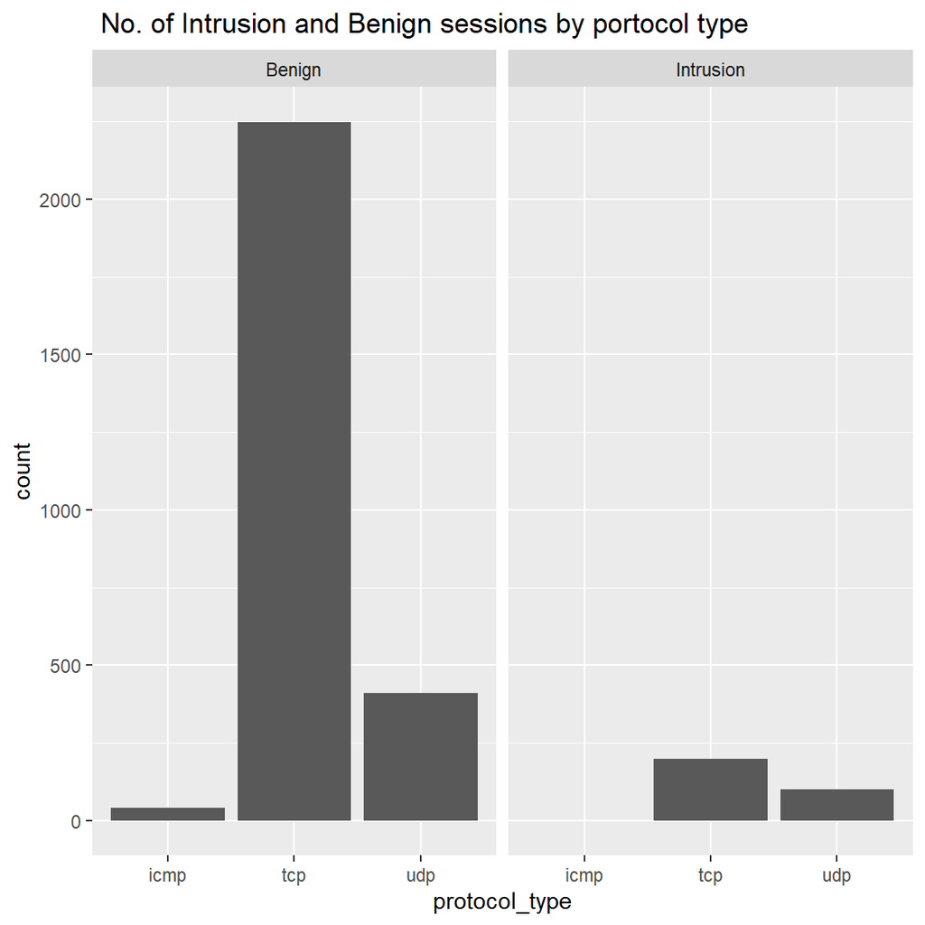

```r
ggplot(data = network.org.2, aes(x = protocol_type)) + geom_bar() + facet_grid(. ~ is_intrusion) +labs(title = " No. of Intrusion and Benign sessions by portocol type")
```

- We obeserve that the intrusions are only under **tcp** and **udp** protocols. The number of intrusions are more under `protocol` type **tcp** than under **udp**.

**Service Network and Intrusion**

```r
table(network.org.2$service, network.org.2$is_intrusion) %>%
  kable()
```

|  | Benign | Intrusion |
| --- | --- | --- |
| auth | 8 | 0 |
| domain_u | 185 | 0 |
| eco_i | 17 | 0 |
| ecr_i | 10 | 0 |
| finger | 14 | 0 |
| ftp | 12 | 33 |
| ftp_data | 102 | 67 |
| http | 1812 | 100 |
| ntp_u | 21 | 0 |
| other | 58 | 0 |
| pop_3 | 6 | 0 |
| private | 147 | 100 |
| smtp | 290 | 0 |
| telnet | 2 | 0 |
| time | 2 | 0 |
| urp_i | 13 | 0 |

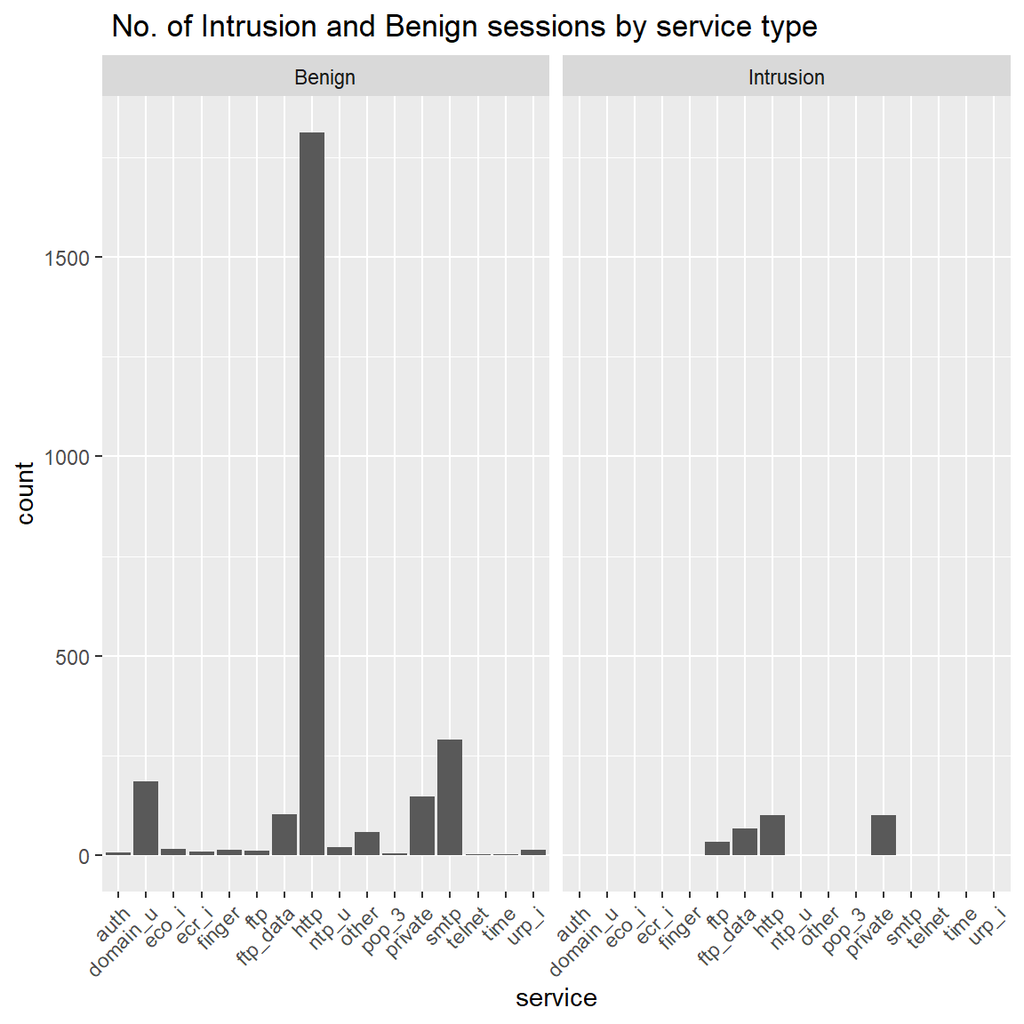

```r
ggplot(data = network.org.2, aes(x = service)) + geom_bar() + facet_grid(. ~ is_intrusion) + theme(axis.text.x = element_text(angle = 45, hjust = 1)) +labs(title = " No. of Intrusion and Benign sessions by service type")
```

- We obeserve that the intrusions are only under **ftp**, **ftp_data**, **http**, and **private** `service` types. The number of intrusions are higher for **private** and **http** `service` types.

**Flag status and Intrusion**

```r
table(network.org.2$flag, network.org.2$is_intrusion) %>%
  kable()
```

|  | Benign | Intrusion |
| --- | --- | --- |
| REJ | 154 | 0 |
| RSTO | 1 | 0 |
| RSTR | 0 | 65 |
| S0 | 0 | 33 |
| S3 | 0 | 2 |
| SF | 2544 | 200 |

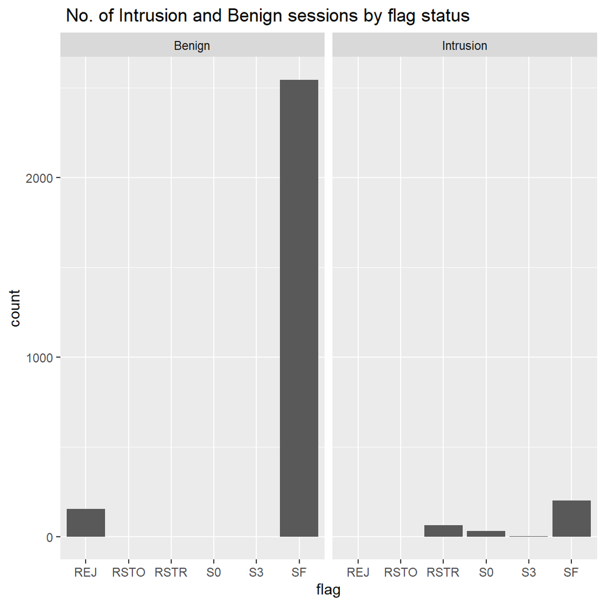

```r
ggplot(data = network.org.2, aes(x = flag)) + geom_bar() + facet_grid(. ~ is_intrusion) +labs(title = " No. of Intrusion and Benign sessions by flag status")
```

**Observations by protocol and service**

```r
network.org.2 %>%
  tab_cells(service) %>%
  tab_cols(protocol_type) %>%
  tab_stat_cases() %>%
  tab_pivot() %>%
  tab_caption("All observations by protocol and service")
```

| All observations by protocol and service | All observations by protocol and service protocol_type icmp | All observations by protocol and service protocol_type tcp | All observations by protocol and service protocol_type udp |
| --- | --- | --- | --- |
| service |  |  |  |
| auth |  | 8 |  |
| domain_u |  |  | 185 |
| eco_i | 17 |  |  |
| ecr_i | 10 |  |  |
| finger |  | 14 |  |
| ftp |  | 45 |  |
| ftp_data |  | 169 |  |
| http |  | 1912 |  |
| ntp_u |  |  | 21 |
| other |  | 1 | 57 |
| pop_3 |  | 6 |  |
| private |  |  | 247 |
| smtp |  | 290 |  |
| telnet |  | 2 |  |
| time |  | 2 |  |
| urp_i | 13 |  |  |
| #Total cases | 40 | 2449 | 510 |

```r
network.org.int %>%
  tab_cells(service) %>%
  tab_cols(protocol_type) %>%
  tab_stat_cases() %>%
  tab_pivot() %>%
  tab_caption("Intrusion count by protocol and service")
```

| Intrusion count by protocol and service | Intrusion count by protocol and service protocol_type icmp | Intrusion count by protocol and service protocol_type tcp | Intrusion count by protocol and service protocol_type udp |
| --- | --- | --- | --- |
| service |  |  |  |
| auth |  |  |  |
| domain_u |  |  |  |
| eco_i |  |  |  |
| ecr_i |  |  |  |
| finger |  |  |  |
| ftp |  | 33 |  |
| ftp_data |  | 67 |  |
| http |  | 100 |  |
| ntp_u |  |  |  |
| other |  |  |  |
| pop_3 |  |  |  |
| private |  |  | 100 |
| smtp |  |  |  |
| telnet |  |  |  |
| time |  |  |  |
| urp_i |  |  |  |
| #Total cases |  | 200 | 100 |

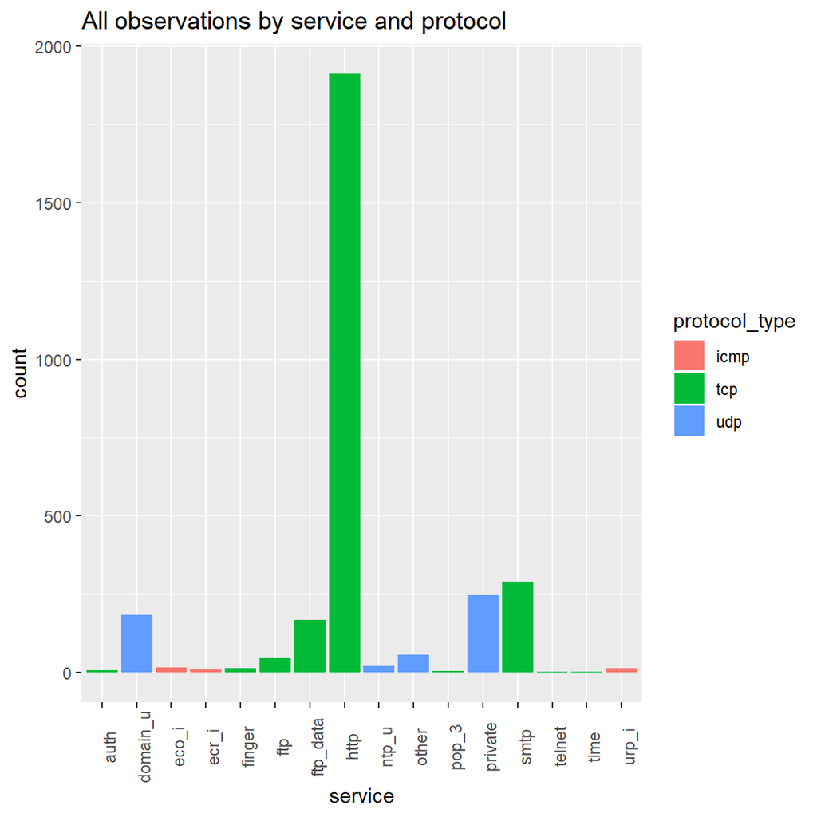

```r
base +
  geom_bar(aes(x = service, fill = protocol_type)) +
  labs(title = "All observations by service and protocol") +
  theme(axis.text.x = element_text(angle = 90))
```

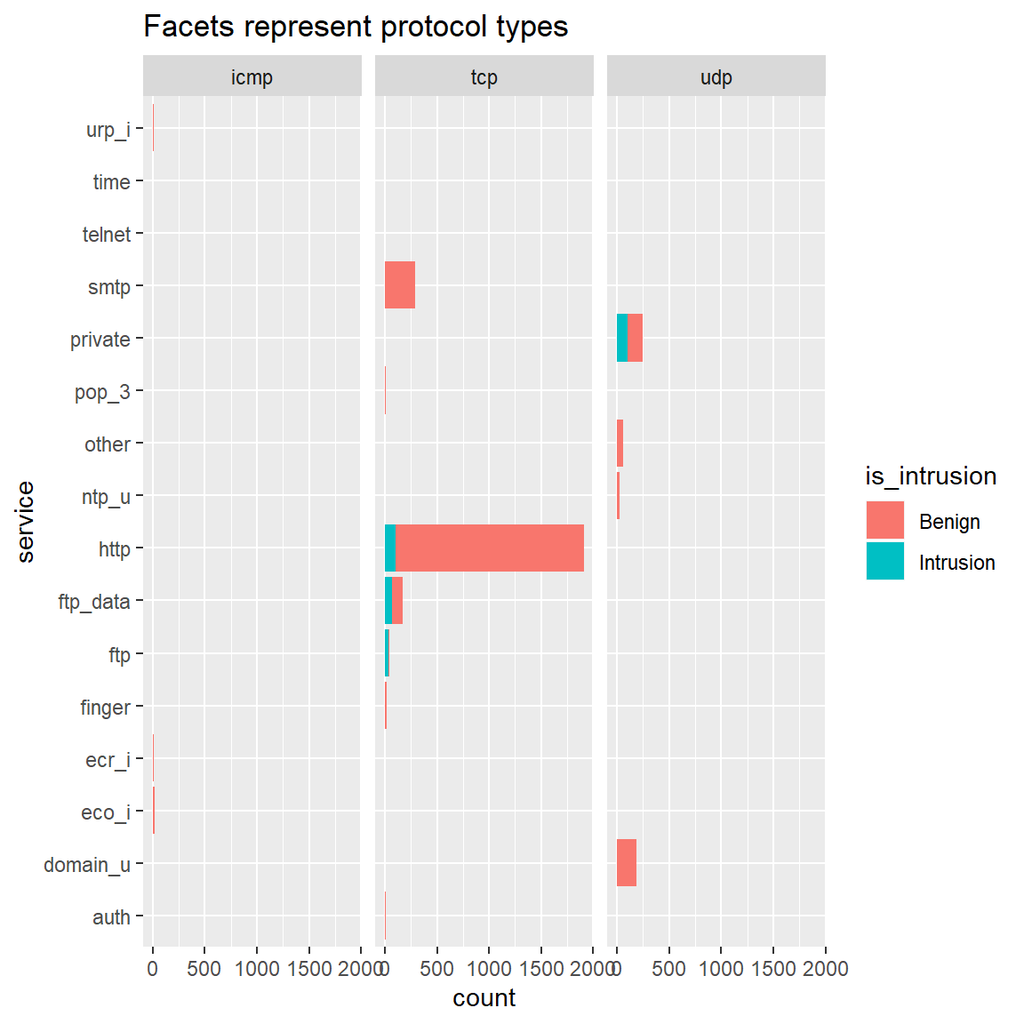

```r
base +
  geom_bar(aes(x = service, fill = is_intrusion)) +
  facet_wrap(~protocol_type, nrow = 1) +
  coord_flip() +
  labs(title = "Facets represent protocol types")
```

- Very few observations are `protocol_type` **icmp** and no intrusions occur via this protocol.
- Most observations are `protocol_type` **tcp**, `service` **http**. Most intrusions come in this group, as well as `protocol_type` **udp**, `service` **private**.

```r
network.org.int %>%
  tab_cells(service) %>%
  tab_cols(protocol_type) %>%
  tab_stat_tpct() %>%
  tab_pivot() %>%
  tab_caption("Share of known intrusions by protocol and service")
```

| Share of known intrusions by protocol and service | Share of known intrusions by protocol and service protocol_type icmp | Share of known intrusions by protocol and service protocol_type tcp | Share of known intrusions by protocol and service protocol_type udp |
| --- | --- | --- | --- |
| service |  |  |  |
| auth |  |  |  |
| domain_u |  |  |  |
| eco_i |  |  |  |
| ecr_i |  |  |  |
| finger |  |  |  |
| ftp |  | 11.0 |  |
| ftp_data |  | 22.3 |  |
| http |  | 33.3 |  |
| ntp_u |  |  |  |
| other |  |  |  |
| pop_3 |  |  |  |
| private |  |  | 33.3 |
| smtp |  |  |  |
| telnet |  |  |  |
| time |  |  |  |
| urp_i |  |  |  |
| #Total cases |  | 200 | 100 |

- 67% of known intrusions in the dataset are `service` **ftp**, **ftp_data** and **http**.

**Observations by flag and service**

```r
network.org.2 %>%
  tab_cells(service) %>%
  tab_cols(flag) %>%
  tab_stat_cases() %>%
  tab_pivot() %>%
  tab_caption("All observations by flag and service")
```

| All observations by flag and service | All observations by flag and service flag REJ | All observations by flag and service flag RSTO | All observations by flag and service flag RSTR | All observations by flag and service flag S0 | All observations by flag and service flag S3 | All observations by flag and service flag SF |
| --- | --- | --- | --- | --- | --- | --- |
| service |  |  |  |  |  |  |
| auth |  |  |  |  |  | 8 |
| domain_u |  |  |  |  |  | 185 |
| eco_i |  |  |  |  |  | 17 |
| ecr_i |  |  |  |  |  | 10 |
| finger |  |  |  |  |  | 14 |
| ftp |  |  |  |  |  | 45 |
| ftp_data |  |  |  |  |  | 169 |
| http | 154 | 1 | 65 | 33 | 2 | 1657 |
| ntp_u |  |  |  |  |  | 21 |
| other |  |  |  |  |  | 58 |
| pop_3 |  |  |  |  |  | 6 |
| private |  |  |  |  |  | 247 |
| smtp |  |  |  |  |  | 290 |
| telnet |  |  |  |  |  | 2 |
| time |  |  |  |  |  | 2 |
| urp_i |  |  |  |  |  | 13 |
| #Total cases | 154 | 1 | 65 | 33 | 2 | 2744 |

```r
network.org.int %>%
  tab_cells(service) %>%
  tab_cols(flag) %>%
  tab_stat_cases() %>%
  tab_pivot() %>%
  tab_caption("Intrusion count by flag and service")
```

| Intrusion count by flag and service | Intrusion count by flag and service flag REJ | Intrusion count by flag and service flag RSTO | Intrusion count by flag and service flag RSTR | Intrusion count by flag and service flag S0 | Intrusion count by flag and service flag S3 | Intrusion count by flag and service flag SF |
| --- | --- | --- | --- | --- | --- | --- |
| service |  |  |  |  |  |  |
| auth |  |  |  |  |  |  |
| domain_u |  |  |  |  |  |  |
| eco_i |  |  |  |  |  |  |
| ecr_i |  |  |  |  |  |  |
| finger |  |  |  |  |  |  |
| ftp |  |  |  |  |  | 33 |
| ftp_data |  |  |  |  |  | 67 |
| http |  |  | 65 | 33 | 2 |  |
| ntp_u |  |  |  |  |  |  |
| other |  |  |  |  |  |  |
| pop_3 |  |  |  |  |  |  |
| private |  |  |  |  |  | 100 |
| smtp |  |  |  |  |  |  |
| telnet |  |  |  |  |  |  |
| time |  |  |  |  |  |  |
| urp_i |  |  |  |  |  |  |
| #Total cases |  |  | 65 | 33 | 2 | 200 |

- ALL `service` **http** intrusions receive `flag` **RSTR**, **S0**, and **S3**. This is interesting because `service` **http**, `flag` **SF** represent the majority of all observations. This is a clear interaction of terms that models will need to identify.

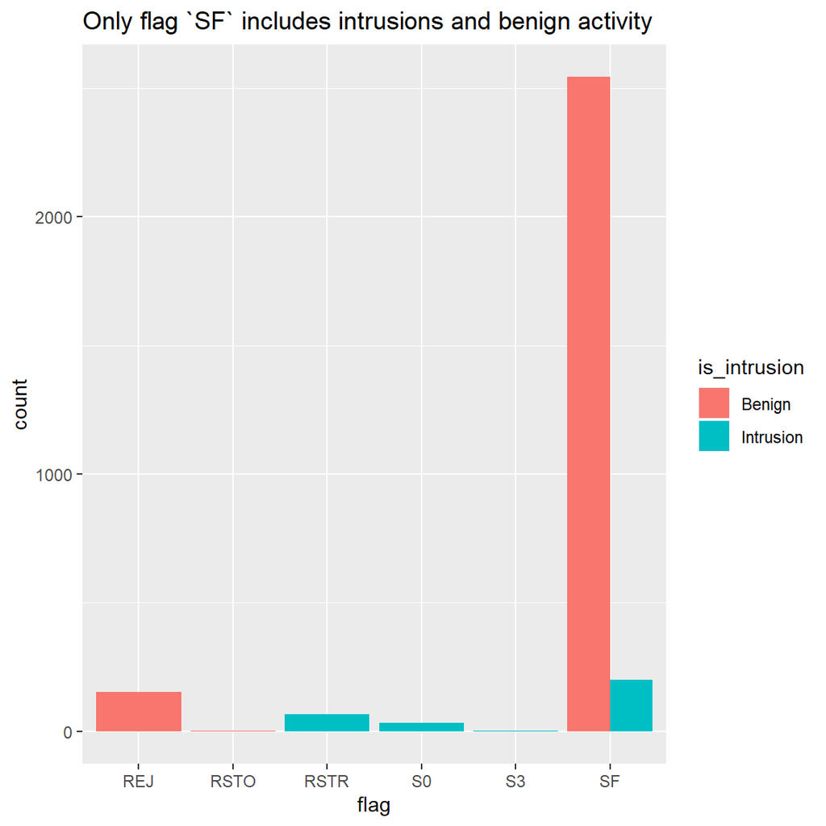

```r
base +
  geom_bar(aes(x = flag, fill = is_intrusion), position = "dodge") +
  labs(title = "Only flag `SF` includes intrusions and benign activity")
```

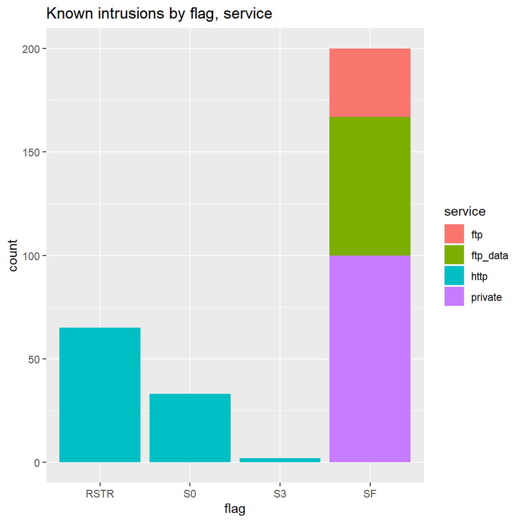

```r
base.int +
  geom_bar(aes(x = flag, fill = service)) +
  labs(title = "Known intrusions by flag, service")
```

**Mean duration**

```r
duration.tbl <- network.org.int %>%
  group_by(protocol_type, service) %>%
  summarise(mean_duration_of_intrusions = round(mean(duration),0))
duration.tbl
```

```
## # A tibble: 4 x 3
## # Groups:   protocol_type [2]
##   protocol_type service  mean_duration_of_intrusions
##   <fct>         <fct>                          <dbl>
## 1 tcp           ftp                              282
## 2 tcp           ftp_data                         125
## 3 tcp           http                             749
## 4 udp           private                            0
```

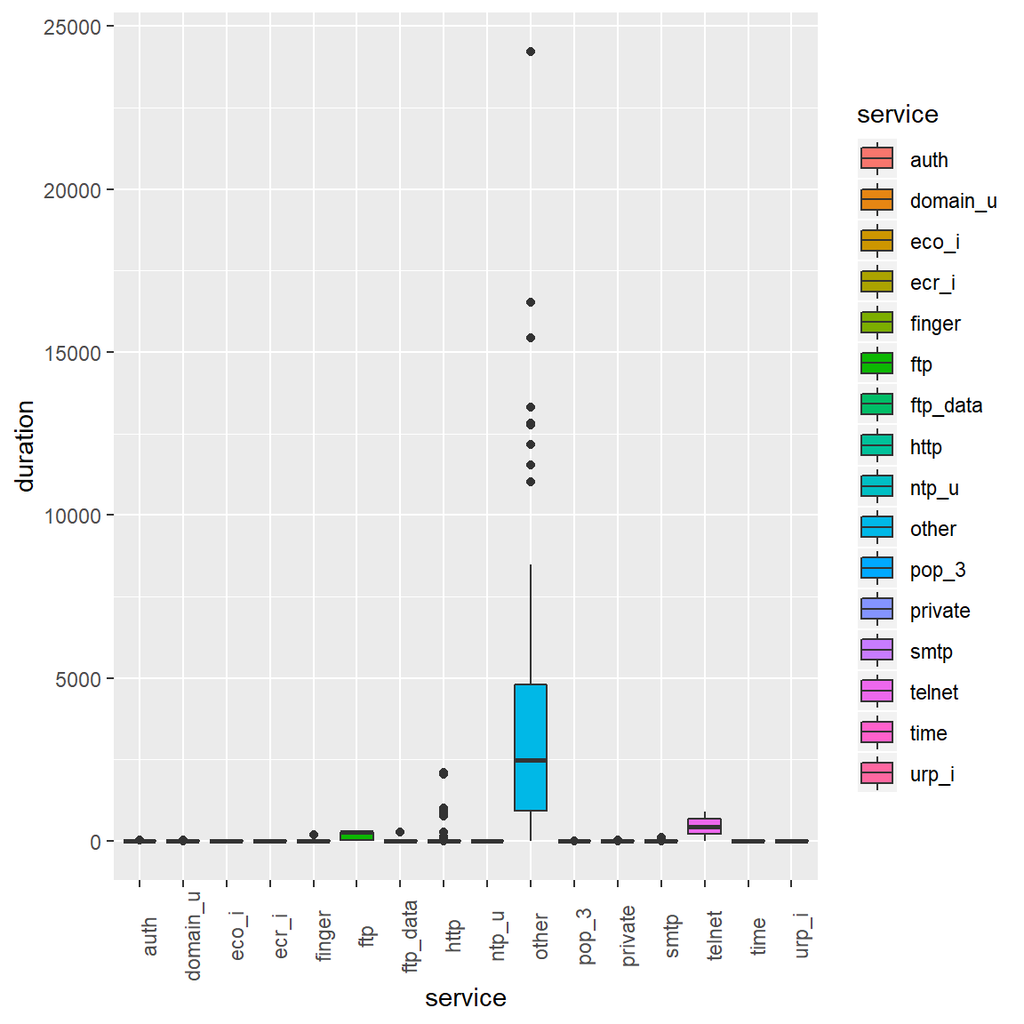

```r
base +
  geom_boxplot(aes(x = service, y = duration, fill= service)) +
  theme(axis.text.x = element_text(angle = 90))
```

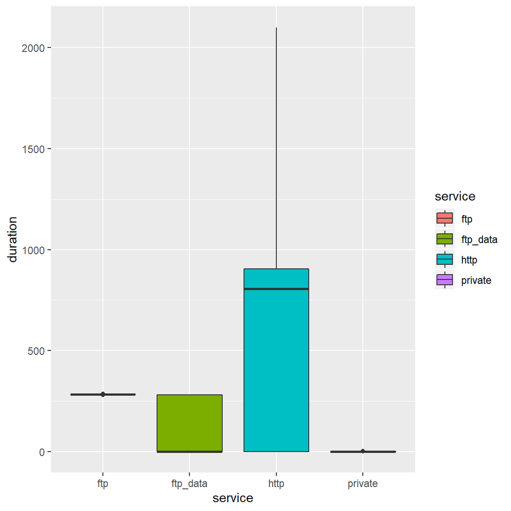

```r
base.int +
  geom_boxplot(aes(x = service, y = duration, fill= service))
```

- Only `service` **other** has high variance in duration, but there are no intrusions in this service.
- `service` **http** has several outliers, presumably intrusions.

```r
network[network$service==8,] %>%
  tab_cells(duration) %>%
  tab_cols(is_intrusion) %>%
  tab_stat_mean() %>%
  tab_pivot() %>%
  tab_caption("Service 'http' mean duration by 'is_intrusion'")
```

| Service ‘http’ mean duration by ‘is_intrusion’ | Service ‘http’ mean duration by ‘is_intrusion’ is_intrusion 0 | Service ‘http’ mean duration by ‘is_intrusion’ is_intrusion 1 |
| --- | --- | --- |
| duration |  |  |
| Mean | 0.4 | 749.4 |

- The table above suggests the outliers in `service` **http** are likely intrusions!. This is another useful interaction.

**Source and destination bytes.**

**Source Bytes**

```r
# Make NA values '-' for cleaner tables with kable()
options(knitr.kable.NA = '________')

tbl.src.service <- network.org.2 %>%
  group_by(service, flag) %>%
  summarise(mean.src.bytes = round(mean(src_bytes),0))

src.spread <- spread(tbl.src.service, flag, mean.src.bytes)
kable(src.spread, format = "markdown", caption = "Mean source bytes")
```

| service | REJ | RSTO | RSTR | S0 | S3 | SF |
| --- | --- | --- | --- | --- | --- | --- |
| auth | ________ | ________ | ________ | ________ | ________ | 11 |
| domain_u | ________ | ________ | ________ | ________ | ________ | 44 |
| eco_i | ________ | ________ | ________ | ________ | ________ | 30 |
| ecr_i | ________ | ________ | ________ | ________ | ________ | 30 |
| finger | ________ | ________ | ________ | ________ | ________ | 8 |
| ftp | ________ | ________ | ________ | ________ | ________ | 258 |
| ftp_data | ________ | ________ | ________ | ________ | ________ | 52279 |
| http | 0 | 0 | 57509 | 0 | 66724 | 266 |
| ntp_u | ________ | ________ | ________ | ________ | ________ | 48 |
| other | ________ | ________ | ________ | ________ | ________ | 155 |
| pop_3 | ________ | ________ | ________ | ________ | ________ | 58 |
| private | ________ | ________ | ________ | ________ | ________ | 105 |
| smtp | ________ | ________ | ________ | ________ | ________ | 1706 |
| telnet | ________ | ________ | ________ | ________ | ________ | 636 |
| time | ________ | ________ | ________ | ________ | ________ | 0 |
| urp_i | ________ | ________ | ________ | ________ | ________ | 174 |

```r
tbl.src.service.int <- network.org.int %>%
  group_by(service, flag) %>%
  summarise(mean.src.bytes = round(mean(src_bytes),0))

src.int.spread <- spread(tbl.src.service.int, flag, mean.src.bytes)
kable(src.int.spread, format = "markdown", caption = "Mean source bytes")
```

| service | RSTR | S0 | S3 | SF |
| --- | --- | --- | --- | --- |
| ftp | ________ | ________ | ________ | 160 |
| ftp_data | ________ | ________ | ________ | 127000 |
| http | 57509 | 0 | 66724 | ________ |
| private | ________ | ________ | ________ | 105 |

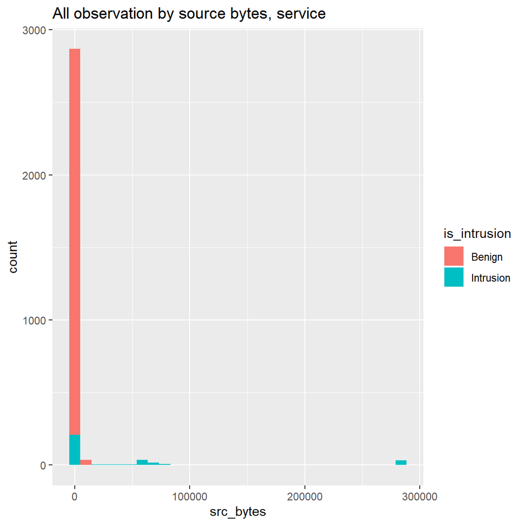

```r
base +
  geom_histogram(aes(x = src_bytes, fill = is_intrusion)) +
  labs(title = "All observation by source bytes, service")
```

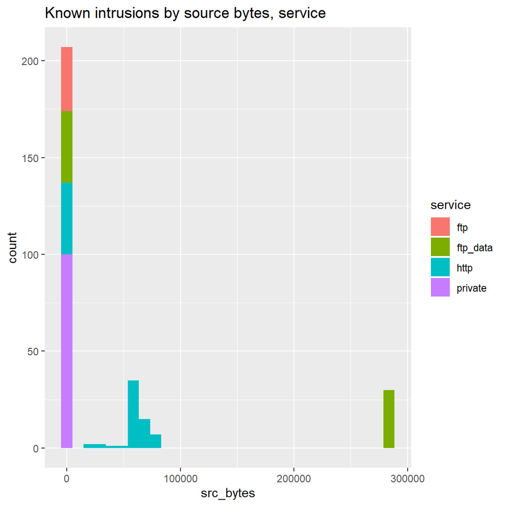

```r
base.int +
  geom_histogram(aes(x = src_bytes, fill = service)) +
  labs(title = "Known intrusions by source bytes, service")
```

**Destination bytes**

```r
tbl.dst <- network.org.2 %>%
  group_by(service, flag) %>%
  summarise(mean.dst.bytes = round(mean(dst_bytes),0))

dst.spread <- spread(tbl.dst, flag, mean.dst.bytes)
kable(dst.spread, format = "markdown", caption = "Mean destination bytes")
```

| service | REJ | RSTO | RSTR | S0 | S3 | SF |
| --- | --- | --- | --- | --- | --- | --- |
| auth | ________ | ________ | ________ | ________ | ________ | 38 |
| domain_u | ________ | ________ | ________ | ________ | ________ | 64 |
| eco_i | ________ | ________ | ________ | ________ | ________ | 0 |
| ecr_i | ________ | ________ | ________ | ________ | ________ | 0 |
| finger | ________ | ________ | ________ | ________ | ________ | 155 |
| ftp | ________ | ________ | ________ | ________ | ________ | 858 |
| ftp_data | ________ | ________ | ________ | ________ | ________ | 0 |
| http | 0 | 0 | 0 | 0 | 0 | 4624 |
| ntp_u | ________ | ________ | ________ | ________ | ________ | 48 |
| other | ________ | ________ | ________ | ________ | ________ | 85 |
| pop_3 | ________ | ________ | ________ | ________ | ________ | 2738 |
| private | ________ | ________ | ________ | ________ | ________ | 128 |
| smtp | ________ | ________ | ________ | ________ | ________ | 356 |
| telnet | ________ | ________ | ________ | ________ | ________ | 33843 |
| time | ________ | ________ | ________ | ________ | ________ | 4 |
| urp_i | ________ | ________ | ________ | ________ | ________ | 0 |

```r
tbl.dst.int <- network.org.int %>%
  group_by(service, flag) %>%
  summarise(mean.dst.bytes = round(mean(dst_bytes),0))

dst.int.spread <- spread(tbl.dst.int, flag, mean.dst.bytes)
kable(dst.int.spread, format = "markdown", caption = "Mean destination bytes")
```

| service | RSTR | S0 | S3 | SF |
| --- | --- | --- | --- | --- |
| ftp | ________ | ________ | ________ | 597 |
| ftp_data | ________ | ________ | ________ | 0 |
| http | 0 | 0 | 0 | ________ |
| private | ________ | ________ | ________ | 143 |

-`service` http intrusions clearly differ in that they have 0 destination bytes.

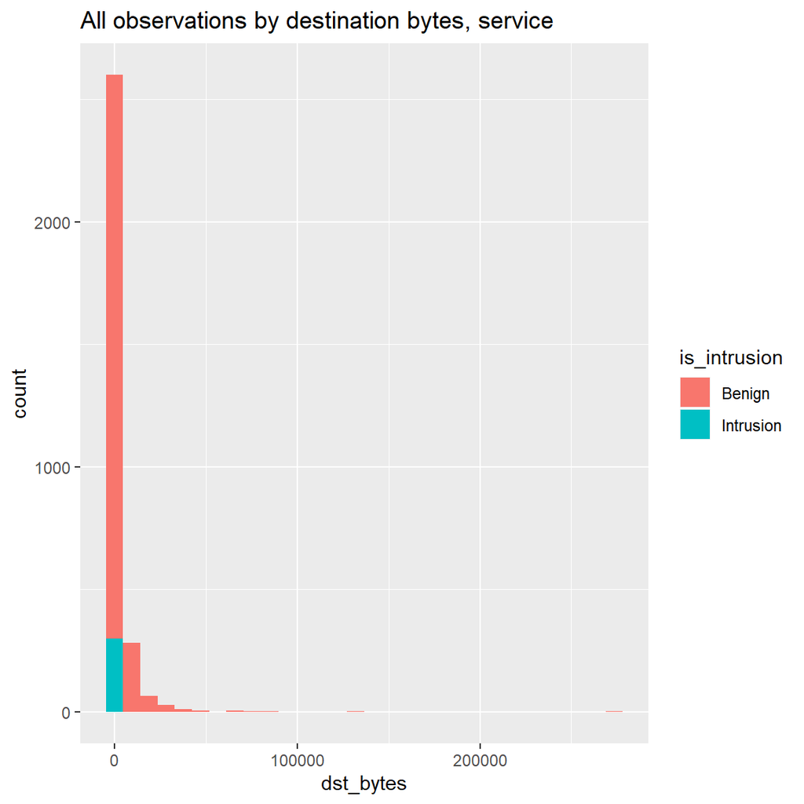

```r
base +
  geom_histogram(aes(x = dst_bytes, fill = is_intrusion)) +
  labs(title = "All observations by destination bytes, service")
```

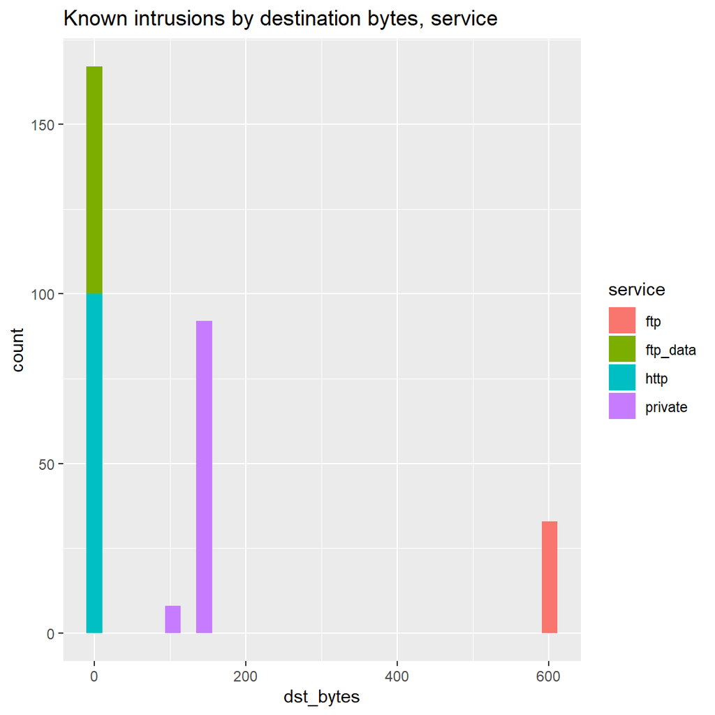

```r
base.int +
  geom_histogram(aes(x = dst_bytes, fill = service)) +
  labs(title = "Known intrusions by destination bytes, service")
```

**Association and correlation**

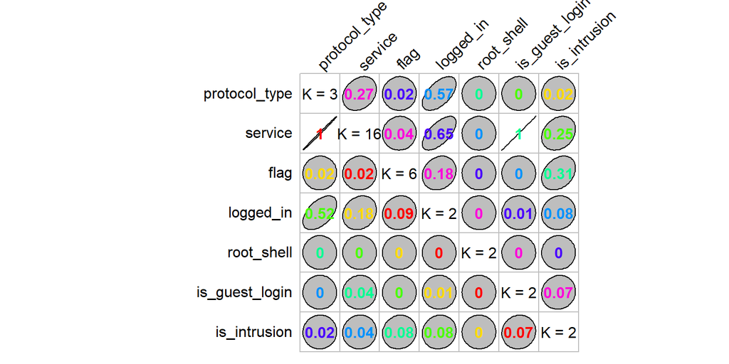

```r
# Association matrix for factor variables
# For explanation, see: https://cran.r-project.org/web/packages/GoodmanKruskal/vignettes/GoodmanKruskal.html
# If required: install.packages("GoodmanKruskal")

var.factors <- c('protocol_type','service','flag','logged_in','root_shell','is_guest_login','is_intrusion')
cor.frame <- subset(network, select = var.factors)
gk.matrix <- GKtauDataframe(cor.frame)
plot(gk.matrix)
```

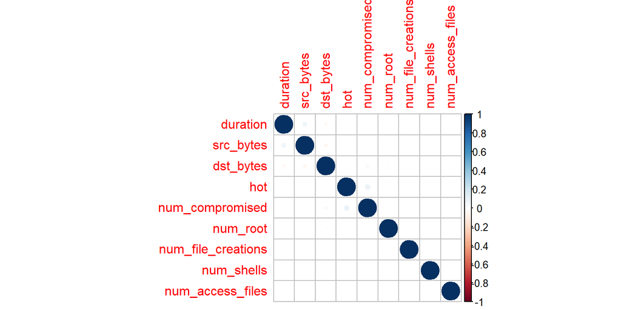

```r
# Correlation matrix, all predictors required to be numeric
# If required: install.packages("corrplot")
cor.frame.2 <- select(network, -var.factors)
cor.matrix <- cor(cor.frame.2)
cor.tbl <- kable(cor.matrix, format = "markdown", digits = 4)
corrplot(cor.matrix)
```

```r
#cor.tbl
```

- From above, the standard correlation matrix suggests there are no significantly correlated continuous predictors (i.e., nothing duplicative about these).
- Importantly, the GK association matrix shows that `service` perfectly predicts `protocol_type` and `is_guest_login`. Also, both `service` and `flag` have relatively stronger forward associations with `is_intrusion`.

### Multiple Factor Analysis

> The multifactor analysis below is conducted on a dataframe including our known intrusions. The tables and charts pick up on the interactions that were becoming clear in the basic EDA. That is, the MFA analysis shows in greater detail that there appear to be repeated and identifiable attack vectors among our intrusions that can be identified on the basis of certain factors (e.g., service and flag) and continuous variables (e.g., bytes and duration).

> Such identifiable attacks can be captured quickly in an Intrusion Detection System that has some element of supervised learning.

**MFA**

```r
#MFA analysis using FactoMineR library - More information about Multiple Factor Analysis can be found on - https://www.rdocumentation.org/packages/FactoMineR/versions/2.2/topics/MFA

newDF <- network.int[,c("duration","src_bytes","dst_bytes","protocol_type","service","flag","logged_in","is_guest_login")]
res.MFA<-MFA(newDF,group=c(1,2,3,2), type=c("s","s","n","n"),ncp=2,name.group=c("duration","bytes","proto_info","login_info"),graph=FALSE)#creating MFA output
summary(res.MFA)
```

```
##
## Call:
## MFA(base = newDF, group = c(1, 2, 3, 2), type = c("s", "s", "n",
##      "n"), ncp = 2, name.group = c("duration", "bytes", "proto_info",
##      "login_info"), graph = FALSE)
##
##
## Eigenvalues
##                        Dim.1   Dim.2   Dim.3   Dim.4   Dim.5   Dim.6
## Variance               2.199   2.039   0.985   0.670   0.402   0.262
## % of var.             32.948  30.556  14.764  10.043   6.018   3.931
## Cumulative % of var.  32.948  63.504  78.268  88.311  94.329  98.259
##                        Dim.7   Dim.8   Dim.9  Dim.10  Dim.11  Dim.12
## Variance               0.111   0.005   0.001   0.000   0.000   0.000
## % of var.              1.661   0.071   0.008   0.000   0.000   0.000
## Cumulative % of var.  99.920  99.992 100.000 100.000 100.000 100.000
##                       Dim.13  Dim.14  Dim.15  Dim.16  Dim.17
## Variance               0.000   0.000   0.000   0.000   0.000
## % of var.              0.000   0.000   0.000   0.000   0.000
## Cumulative % of var. 100.000 100.000 100.000 100.000 100.000
##
## Groups
##                    Dim.1    ctr   cos2    Dim.2    ctr   cos2
## duration        |  0.861 39.147  0.741 |  0.011  0.560  0.000 |
## bytes           |  0.058  2.654  0.003 |  0.849 41.617  0.560 |
## proto_info      |  0.765 34.773  0.318 |  0.436 21.392  0.103 |
## login_info      |  0.515 23.426  0.238 |  0.743 36.430  0.495 |
##
## Individuals (the 10 first)
##                    Dim.1    ctr   cos2    Dim.2    ctr   cos2
## 16              | -1.405  0.299  0.704 | -0.005  0.000  0.000 |
## 68              | -1.392  0.294  0.697 | -0.124  0.003  0.006 |
## 73              | -1.405  0.299  0.704 | -0.005  0.000  0.000 |
## 76              | -1.405  0.299  0.704 | -0.005  0.000  0.000 |
## 82              | -1.405  0.299  0.704 | -0.002  0.000  0.000 |
## 107             | -1.405  0.299  0.704 | -0.005  0.000  0.000 |
## 124             | -1.405  0.299  0.704 | -0.005  0.000  0.000 |
## 135             | -1.405  0.299  0.704 | -0.002  0.000  0.000 |
## 137             | -1.405  0.299  0.704 | -0.002  0.000  0.000 |
## 146             | -1.405  0.299  0.704 | -0.008  0.000  0.000 |
```

[output cut: 15 more lines]

```
## flag_3          |   2.420  10.493   0.877  14.839 |  -0.604   0.761
## flag_4          |  -0.379   0.131   0.026  -1.554 |  -0.765   0.619
## flag_5          |   3.019   0.503   0.134   2.884 |  -0.703   0.032
## flag_6          |  -0.754   3.135   0.694 -12.434 |   0.330   0.697
##                    cos2  v.test
## protocol_type_2   0.000   0.115 |
## protocol_type_3   0.000  -0.115 |
## service_6         0.952  16.599 |
## service_7         0.247  -5.951 |
## service_8         0.133  -5.645 |
## service_12        0.000  -0.115 |
## flag_3            0.055  -3.849 |
## flag_4            0.106  -3.255 |
## flag_5            0.007  -0.697 |
## flag_6            0.133   5.645 |
```

- As we can see from the summary, flag_3, service_8,service_12,protocol_type_3 contribute most to the dimension 1 whereas service_6 contributes dominantly to dimension 2.
- Individuals with these parameters also are represented across these dimensions.

**Individual Factor Analysis Plot**

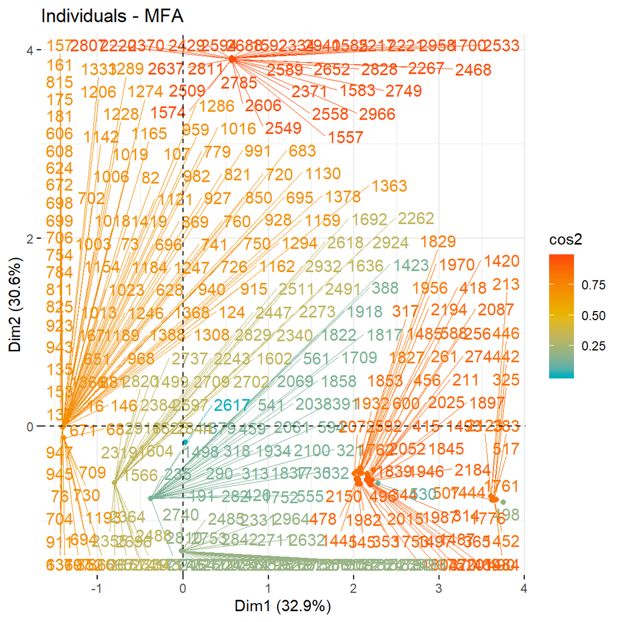

```r
fviz_mfa_ind(res.MFA, col.ind = "cos2",
  gradient.cols = c("#00AFBB", "#E7B800", "#FC4E07"),
  repel = TRUE )
```

- From the plot above we can observe that there are mainly 3 clusters that can be observed. - The ones in the lower left quadrant form one cluster of different intrusions since they are highly correlated to each other and do not contribute much to both dimension 1 and 2. The one in the lower right quadrant forms our second cluster - contribute mainlt to the dimension 1 and the one on the top forms third cluster of intrusions that contribute to the dimension 2.

# Section 2: Classification Models

## Logistic Model

> Logistic Model are simple classification models which can be efficiently used for this dataset which is linearly separable

> Logistic regression is easier to implement, interpret and very efficient to train

> We start by building the model on training data which is validated by 10 fold Cross Validation and check how well it is classifying the training as well as test data.

**Building the logistic model**

```r
logistic.ctrl <- trainControl(method= "cv", number=10) #creating k fold control
logistic.fit<- train(is_intrusion ~. ,data=network.train,trControl= logistic.ctrl, family= binomial(link="logit")) #training the model
```

**Predictions and Confusion Matrix using Logistic Regression Model**

```r
pred.logistic.train<- predict(logistic.fit, network.train) #predicting class for training data
logistic.train.cm <- confusionMatrix(pred.logistic.train, network.train$is_intrusion)# confusion matrix with training predictions
pred.logistic.test <- predict(logistic.fit , network.test)#predicting class for test data
logistic.test.cm <- confusionMatrix(pred.logistic.test, network.test$is_intrusion)# confusion matrix with test predictions
```

**Plot the logistic model**

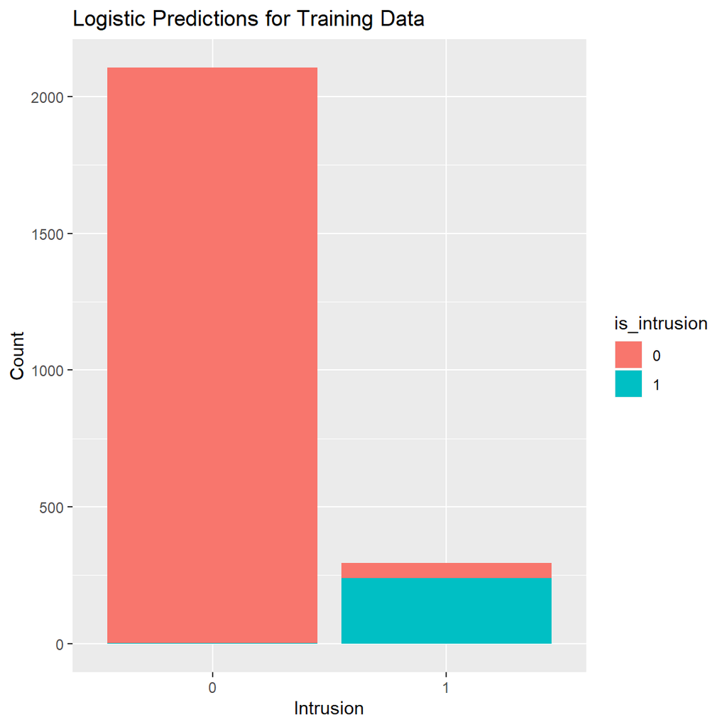

```r
par(mfrow=c(1,2))
logit_hist_train <- ggplot(data= network.train , aes(x= pred.logistic.train, fill= is_intrusion))
#plot the results for predictions on training data
logit_hist_train + geom_histogram(stat="count") +
  labs(x = "Intrusion", y = "Count", title =  "Logistic Predictions for Training Data")
```

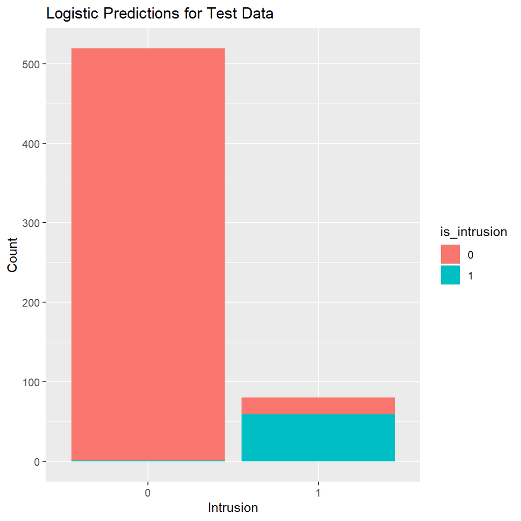

```r
logit_hist_test <- ggplot(data= network.test , aes(x= pred.logistic.test, fill= is_intrusion))
#plot the results for predictions on test data
logit_hist_test + geom_histogram(stat="count") +
  labs(x = "Intrusion", y = "Count", title =  "Logistic Predictions for Test Data")
```

## KNN

> K-nearest neighbors (KNN) is a non-parametric method.The new observations are classified to a class belonging to the majority of its neighbors.The number of neighbors can be pre-determined.

> Below, we will fit a KNN model after scaling the data and run a 10-fold classification. Then we plot a graph to find the level of accuracy vs the k value to find which value may be best suited for the highest accruacy level. In our model, accuracy matters, so does high value of sentivity and it is expensive to not be able to detect intrusions. So the higher the accuracy of that is achieved by the k value, the better it will work for our system.

**Building the KNN Model**

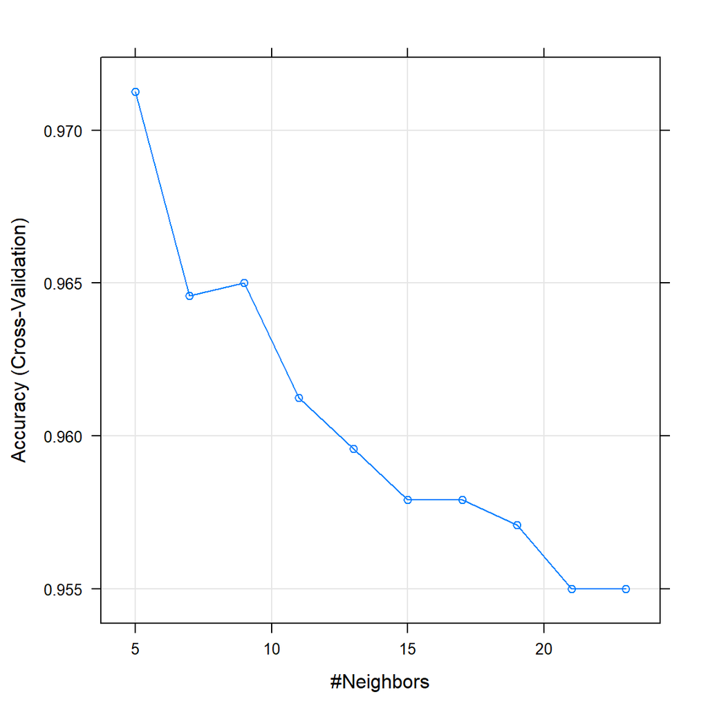

```r
knn.ctrl <- trainControl(method = "cv", number = 10) #Creating 10-fold control

fit.knn <- train(is_intrusion~., data = network.train, method = 'knn', trControl = knn.ctrl, preProcess = c("center","scale"), tuneLength = 10) #training model

plot(fit.knn) #accuracy Vs Neighbors plot for KNN
```

```r
fit.knn #summary of the KNN model
```

```
## k-Nearest Neighbors
##
## 2400 samples
##   15 predictor
##    2 classes: '0', '1'
##
## Pre-processing: centered (34), scaled (34)
## Resampling: Cross-Validated (10 fold)
## Summary of sample sizes: 2160, 2160, 2160, 2160, 2160, 2160, ...
## Resampling results across tuning parameters:
##
##   k   Accuracy   Kappa
##    5  0.9712500  0.8563742
##    7  0.9645833  0.8208262
##    9  0.9650000  0.8256451
##   11  0.9612500  0.8071169
##   13  0.9595833  0.7990696
##   15  0.9579167  0.7930823
##   17  0.9579167  0.7963122
##   19  0.9570833  0.7909101
##   21  0.9550000  0.7828441
##   23  0.9550000  0.7839328
##
## Accuracy was used to select the optimal model using the largest value.
## The final value used for the model was k = 5.
```

**Predictions and Confusion Matrix using KNN Model**

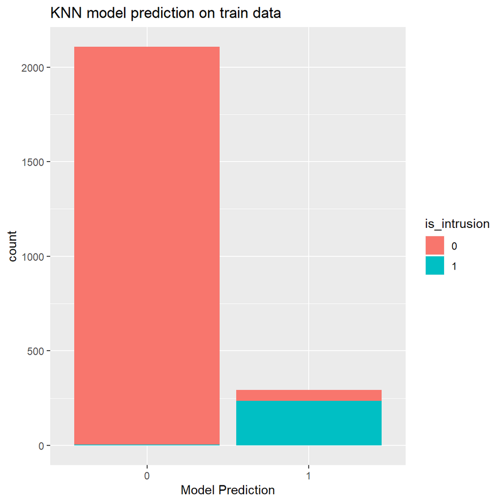

```r
pred.knn.train <- predict(fit.knn, newdata = network.train) #Predicting class for training data
knn.train.cm <- confusionMatrix(pred.knn.train, network.train$is_intrusion) #Confusion Matrix of training data predictions
ggplot(data = network.train, aes(x = pred.knn.train, fill = is_intrusion)) +geom_histogram(stat = "count") + labs(x = "Model Prediction", title = "KNN model prediction on train data")
```

> For the train data, we have an accuracy of 97.46%, Sensitivity/True Positive Rate of 97.36%, and the False Positive Rate = 1.67%

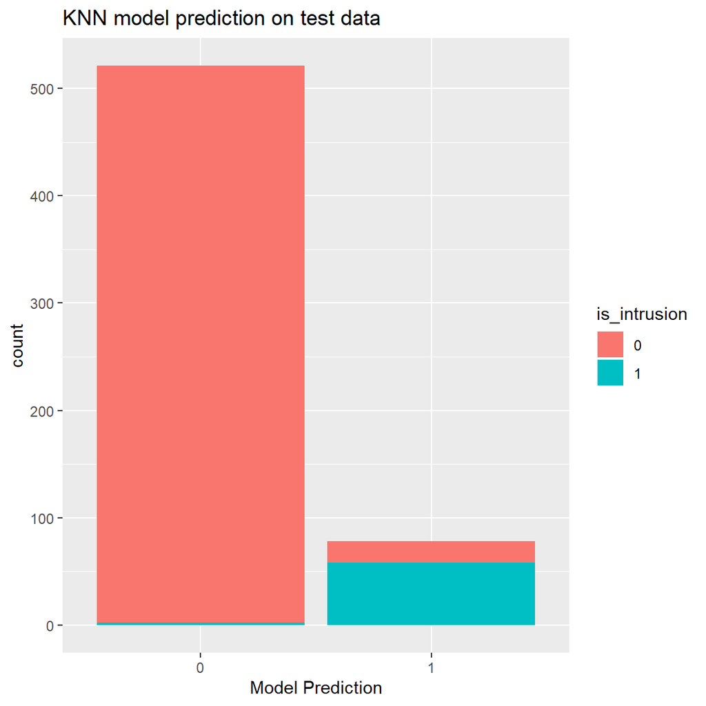

```r
pred.knn.test <- predict(fit.knn, newdata = network.test) #Predicting class for test data
knn.test.cm <- confusionMatrix(pred.knn.test, network.test$is_intrusion) #Confusion Matrix of test data predictions
ggplot(data = network.test, aes(x = pred.knn.test, fill = is_intrusion)) +geom_histogram(stat = "count") + labs(x = "Model Prediction", title = "KNN model prediction on test data")
```

> For the test data, we have an accuracy of 96%, Sensitivity/ True Positive Rate of 96.29%, and the False Positive Rate = 3.3%%

> Overall, the KNN model does a good classification job with decently high accuracy rate.

## Random Forest

> Random forests are bagged decision tree models that split on a subset of features on each split. It can handle binary features, categorical features, and numerical features.

> The random forest starts with a standard machine learning technique called a “decision tree”. In a decision tree, an input is entered at the top and as it traverses down the tree the data gets bucketed into smaller and smaller sets.

**We ﬁrst use classiﬁcation trees to analyze the `network` data set. Using the `tree` command to fit a decision tree to every other variable in the `network` data. Run `summary` on tree object.**

```r
tree.network <- tree(is_intrusion~. ,network)
summary(tree.network)
```

```
##
## Classification tree:
## tree(formula = is_intrusion ~ ., data = network)
## Variables actually used in tree construction:
## [1] "flag"      "service"   "duration"  "src_bytes" "dst_bytes"
## Number of terminal nodes:  7
## Residual mean deviance:  0.104 = 311.2 / 2992
## Misclassification error rate: 0.03368 = 101 / 2999
```

-The `summary()` function lists the variables that are used as internal nodes in the tree, the number of terminal nodes, and the (training) error rate. The number of terminal nodes are 7 in this case. We see that the training error rate is 3.4%

**One of the most attractive properties of trees is that they can be graphically displayed. We use the `plot()` function to display the tree structure, and the `text()` function to display the node labels.**

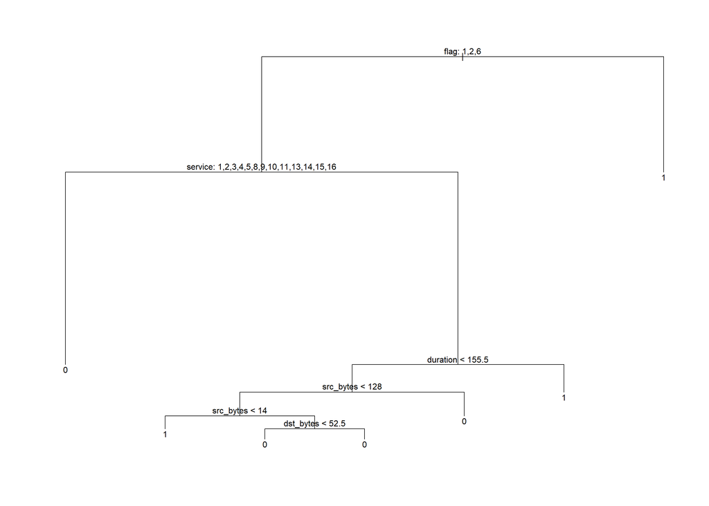

```r
plot(tree.network)
text(tree.network ,pretty =0)
```

-The most important indicators of `is_intrusion` appear to be flag and service.

```r
# This tells us: # misclass, # total
summary(tree.network)$misclass
```

```
## [1]  101 2999
```

```r
misclass.rate <- summary(tree.network)$misclass[1] / summary(tree.network)$misclass[2]
misclass.rate
```

```
## [1] 0.03367789
```

**The output below shows which variables get used, and which ones do not get used. We see that not all variables are used.**

```r
summary(tree.network)$used
```

```
## [1] flag      service   duration  src_bytes dst_bytes
## 16 Levels: <leaf> duration protocol_type service flag ... is_guest_login
```

```r
names(network)[which(!(names(network) %in%summary(tree.network)$used))]
```

```
##  [1] "protocol_type"      "hot"                "logged_in"
##  [4] "num_compromised"    "root_shell"         "num_root"
##  [7] "num_file_creations" "num_shells"         "num_access_files"
## [10] "is_guest_login"     "is_intrusion"
```

-In order to properly evaluate the performance of a classiﬁcation tree on these data, we must estimate the test error rather than simply computing the training error.

**The `predict()` function can be used for this purpose.**

```r
intrusion_test=network.test$is_intrusion
tree.network.train <- tree(is_intrusion~.,network.train)
tree.pred <- predict(tree.network.train,network.test,type="class")
confmat_tree <- confusionMatrix(table(tree.pred,intrusion_test), positive = "1")
confmat_tree
```

```
## Confusion Matrix and Statistics
##
##          intrusion_test
## tree.pred   0   1
##         0 539  18
##         1   0  42
##
##                Accuracy : 0.9699
##                  95% CI : (0.9529, 0.9821)
##     No Information Rate : 0.8998
##     P-Value [Acc > NIR] : 3.930e-11
##
##                   Kappa : 0.8077
##
##  Mcnemar's Test P-Value : 6.151e-05
##
##             Sensitivity : 0.70000
##             Specificity : 1.00000
##          Pos Pred Value : 1.00000
##          Neg Pred Value : 0.96768
##              Prevalence : 0.10017
##          Detection Rate : 0.07012
##    Detection Prevalence : 0.07012
##       Balanced Accuracy : 0.85000
##
##        'Positive' Class : 1
##
```

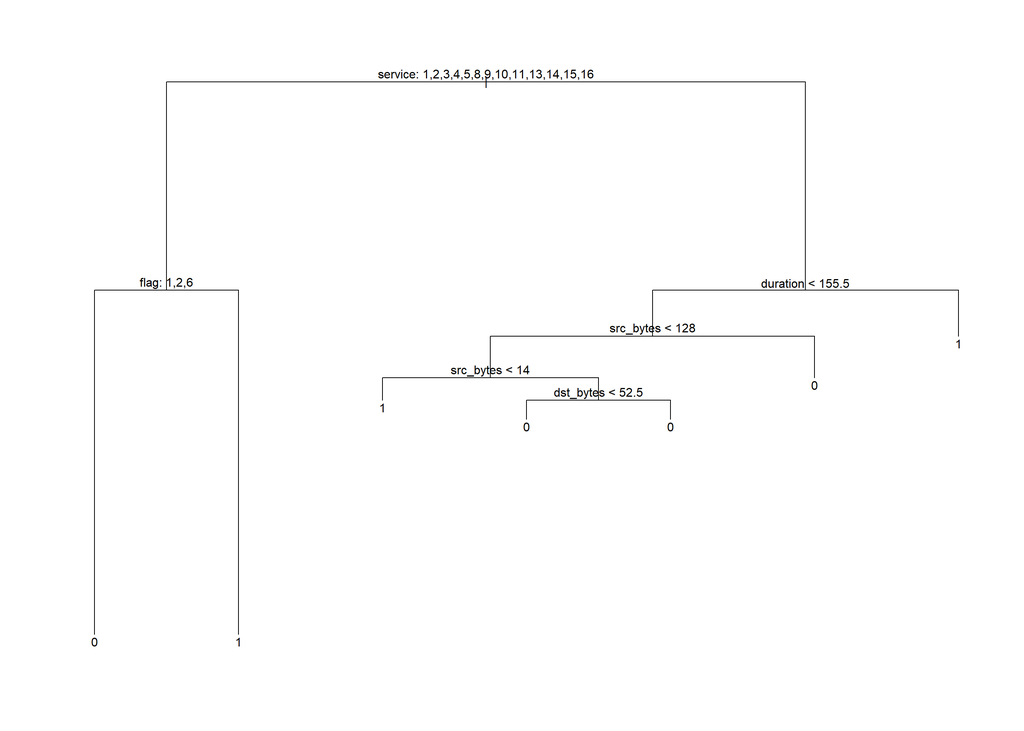

```r
plot(tree.network.train)
text(tree.network.train ,pretty =0)
```

-Service, flag, duration, src_bytes and dst_bytes are used for this decision tree on training data set.

**Next, we consider whether pruning the tree might lead to improved results.**

**The function `cv.tree()` performs cross-validation in order to determine the optimal level of tree complexity. Cost complexity pruning is used in order to select a sequence of trees for consideration.**

```r
cv.network <- cv.tree(tree.network, FUN=prune.misclass)
names(cv.network)
```

```
## [1] "size"   "dev"    "k"      "method"
```

```r
cv.network
```

```
## $size
## [1] 7 6 4 2 1
##
## $dev
## [1] 112 112 137 178 300
##
## $k
## [1]  -Inf   0.0  18.0  31.5 100.0
##
## $method
## [1] "misclass"
##
## attr(,"class")
## [1] "prune"         "tree.sequence"
```

- The cv.tree() function reports the number of terminal nodes of each tree considered (size) as well as the corresponding error rate and the value of the cost-complexity parameter used (k).
- The tree with 6 terminal nodes results in the lowest cross-validation error rate, with 112 cross-validation errors.

**We plot the error rate as a function of both size and k.**

**The following code produces CV error plots indexed by tree size and k (essentially what we called alpha in class).**

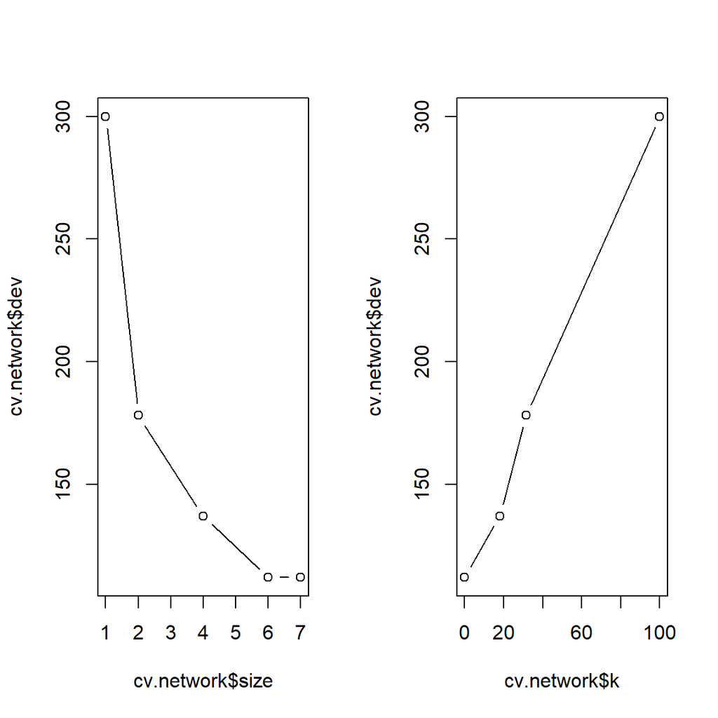

```r
par(mfrow = c(1,2))
plot(cv.network$size, cv.network$dev, type="b")
plot(cv.network$k, cv.network$dev, type="b")
```

**We now apply the `prune.misclass()` function in order to prune the tree to obtain the six-node tree that has the lowest CV error.**

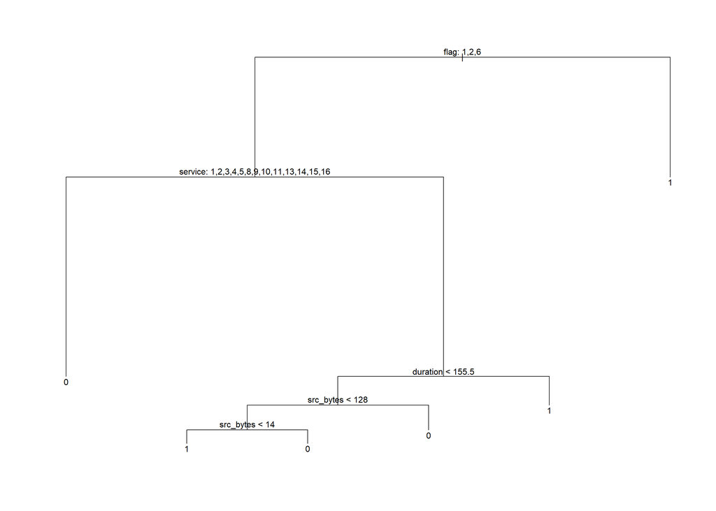

```r
par(mfrow = c(1,1))
prune.network <- prune.misclass(tree.network, best = 6)
#Plot this tree, and overlay text.
plot(prune.network)
text(prune.network, pretty=0)
```

```r
# Variables used
summary(prune.network)$used
```

```
## [1] flag      service   duration  src_bytes
## 16 Levels: <leaf> duration protocol_type service flag ... is_guest_login
```

Once again, we apply the `predict()` function to guage how well does this pruned tree perform on the test data set.

```r
tree.predict <- predict(prune.network, network.test, type="class")
confmat.prunpred <- confusionMatrix(table(tree.predict, intrusion_test),positive = "1")
confmat.prunpred
```

```
## Confusion Matrix and Statistics
##
##             intrusion_test
## tree.predict   0   1
##            0 539  18
##            1   0  42
##
##                Accuracy : 0.9699
##                  95% CI : (0.9529, 0.9821)
##     No Information Rate : 0.8998
##     P-Value [Acc > NIR] : 3.930e-11
##
##                   Kappa : 0.8077
##
##  Mcnemar's Test P-Value : 6.151e-05
##
##             Sensitivity : 0.70000
##             Specificity : 1.00000
##          Pos Pred Value : 1.00000
##          Neg Pred Value : 0.96768
##              Prevalence : 0.10017
##          Detection Rate : 0.07012
##    Detection Prevalence : 0.07012
##       Balanced Accuracy : 0.85000
##
##        'Positive' Class : 1
##
```

```r
# Misclassification rate
1 - (sum(diag(table(tree.predict, intrusion_test))) / sum(table(tree.predict, intrusion_test)))
```

```
## [1] 0.03005008
```

- Pruned tree did not improve the classiﬁcation accuracy.

**We’ll need to construct `rpart` objects instead of `tree` objects in order to use the more advanced plotting routine from the `partykit` library.**

Fitting a decision tree to the data using the `rpart()` function. The syntax is exactly the same as for the `tree` function. Using the `plot` and `text` functions to visualize the tree.

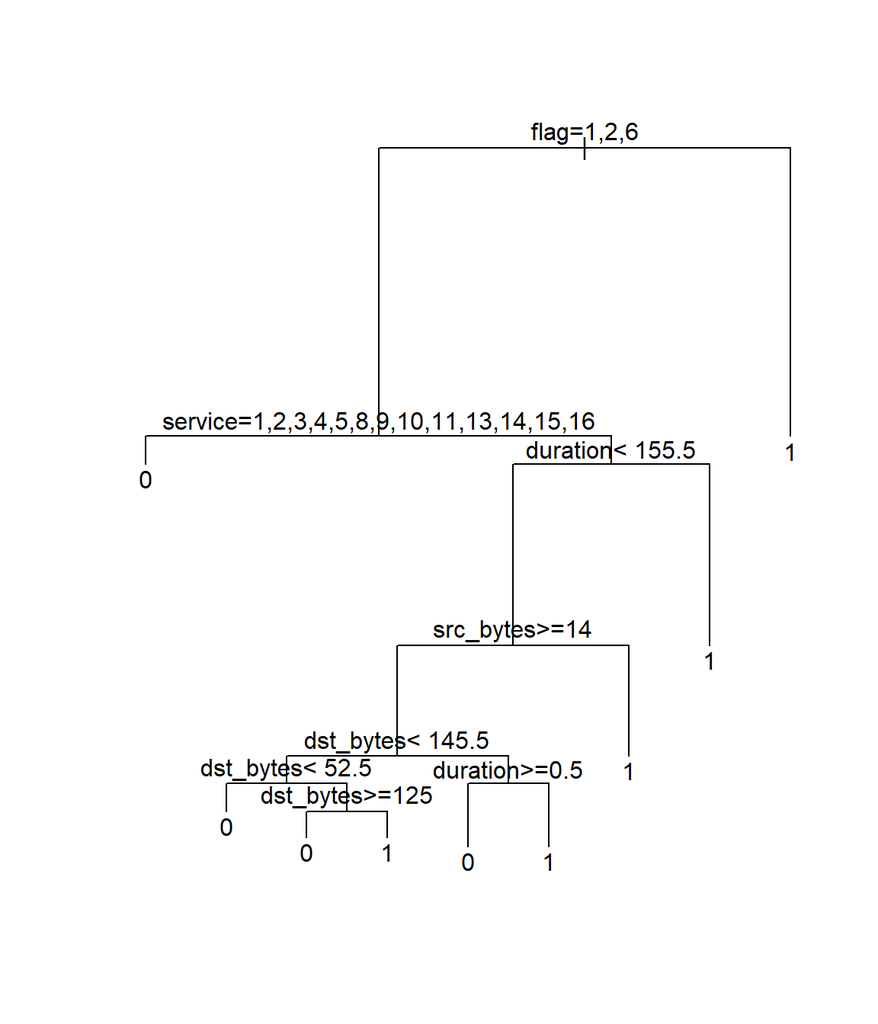

```r
network.tree <- rpart(is_intrusion ~ .,network.train , method="class")

plot(network.tree)
text(network.tree, pretty=0)
```

- Flag, services, duration, src_bytes and dst_bytes are used in this tree. Same as it was as for the `tree` function.

```r
tree_pred <- predict(network.tree,network.test,type="class")
confmat_rpart<- confusionMatrix(table(tree_pred,intrusion_test), positive = "1")
confmat_rpart
```

```
## Confusion Matrix and Statistics
##
##          intrusion_test
## tree_pred   0   1
##         0 520   1
##         1  19  59
##
##                Accuracy : 0.9666
##                  95% CI : (0.9489, 0.9795)
##     No Information Rate : 0.8998
##     P-Value [Acc > NIR] : 4.51e-10
##
##                   Kappa : 0.8366
##
##  Mcnemar's Test P-Value : 0.0001439
##
##             Sensitivity : 0.9833
##             Specificity : 0.9647
##          Pos Pred Value : 0.7564
##          Neg Pred Value : 0.9981
##              Prevalence : 0.1002
##          Detection Rate : 0.0985
##    Detection Prevalence : 0.1302
##       Balanced Accuracy : 0.9740
##
##        'Positive' Class : 1
##
```

- This approach leads to correct predictions for around 0.967 of the network intrusions in the test data set. It is very similar to `tree()` function performed above. However, this decision tree offers a better sensitivity than `tree()` function.

**The `as.party` command converts the `rpart` tree to a `party` object that has a much better plot function. Runing `plot` on the object created below.**

```r
network.party <- as.party(network.tree)
plot(network.party)
```

[output not shown]

**Now we’ll try growing a more complex tree, and pruning them back. The code below grows a tree to a complexity parameter value of `cp = 0.002`, while ensuring that the minimum number of observations that must exist in a node in order for a split to be attempted is `minsplit = 20` observations.**

Running the `plotcp` command on this tree to get a plot of the Cross-validated error. Also look at the `cptable` attribute of this tree. Observe that all of the errors are reported relative to that of the 1-node “tree”.

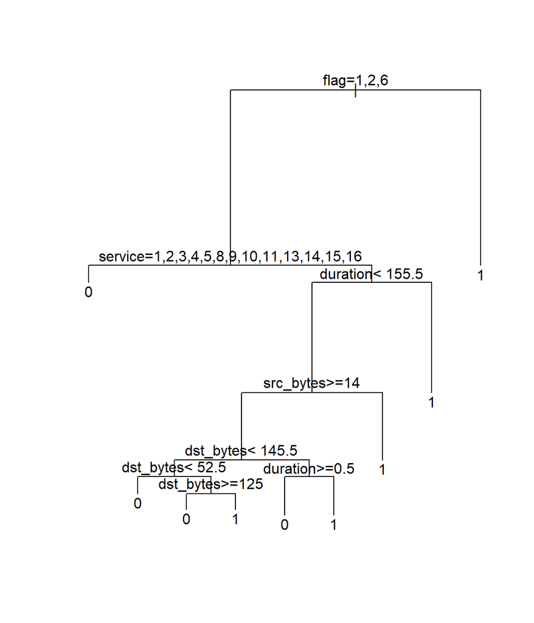

```r
network.full <- rpart(is_intrusion ~ ., data = network.train,
                        control=rpart.control(minsplit=20, cp=0.002))

plot(network.full)
text(network.full, pretty=0)
```

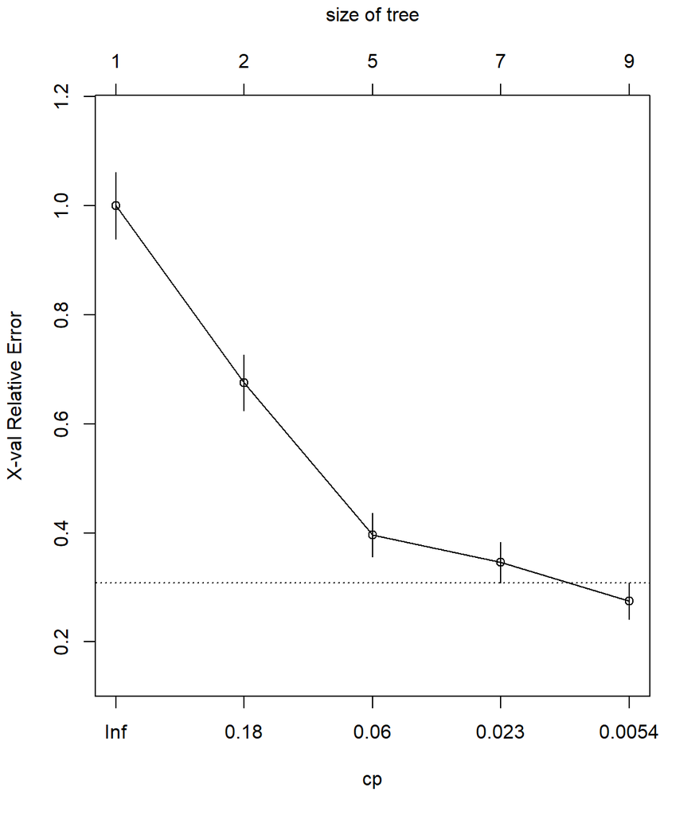

```r
plotcp(network.full)
```

```r
network.full$cptable
```

```
##           CP nsplit rel error    xerror       xstd
## 1 0.32500000      0 1.0000000 1.0000000 0.06123724
## 2 0.10208333      1 0.6750000 0.6750000 0.05121188
## 3 0.03541667      4 0.3458333 0.3958333 0.03979976
## 4 0.01458333      6 0.2750000 0.3458333 0.03729797
## 5 0.00200000      8 0.2458333 0.2750000 0.03338148
```

The horizontal dotted line is 1 standard error above the minimum CV value for the range of `cp` values shown.

```r
network.fullparty <- as.party(network.full)
plot(network.fullparty)
```

[output not shown]

**Appling the 1-SE rule to determine which value of `cp` to use for pruning.**

```r
ind <- which.min(network.full$cptable[,"xerror"])
opt <- network.full$cptable[ind,"xerror"] + network.full$cptable[ind,"xstd"]
cp.pruned <- subset(network.full$cptable,network.full$cptable[,"xerror"]<opt)[1,"CP"]
```

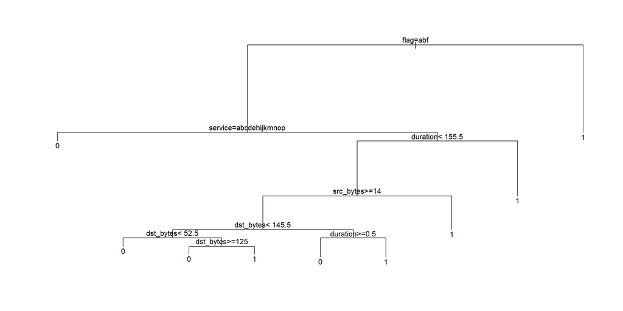

```r
network.pruned <- prune(network.full, cp = cp.pruned)
plot(network.pruned)
text(network.pruned)
```

```r
network.prunedparty <- as.party(network.pruned)
plot(network.prunedparty)
```

[output not shown]

```r
ypred = predict(network.pruned,network.test,type="class")
confmat_prunedpart <- confusionMatrix(table(ypred,intrusion_test), positive = "1")
confmat_prunedpart
```

```
## Confusion Matrix and Statistics
##
##      intrusion_test
## ypred   0   1
##     0 520   1
##     1  19  59
##
##                Accuracy : 0.9666
##                  95% CI : (0.9489, 0.9795)
##     No Information Rate : 0.8998
##     P-Value [Acc > NIR] : 4.51e-10
##
##                   Kappa : 0.8366
##
##  Mcnemar's Test P-Value : 0.0001439
##
##             Sensitivity : 0.9833
##             Specificity : 0.9647
##          Pos Pred Value : 0.7564
##          Neg Pred Value : 0.9981
##              Prevalence : 0.1002
##          Detection Rate : 0.0985
##    Detection Prevalence : 0.1302
##       Balanced Accuracy : 0.9740
##
##        'Positive' Class : 1
##
```

- Pruned version did not improve the classiﬁcation accuracy, similar to what we saw in `tree()` function above.

**let’s try fitting an actual random forest. The default setting is to take `mtry = sqrt(p)` for classification. Fitting a random forest to the training data using `mtry = 5`.**

```r
rf.network <- randomForest(is_intrusion~., data=network.train, mtry=5, importance=TRUE)

rf.network
```

```
##
## Call:
##  randomForest(formula = is_intrusion ~ ., data = network.train,      mtry = 5, importance = TRUE)
##                Type of random forest: classification
##                      Number of trees: 500
## No. of variables tried at each split: 5
##
##         OOB estimate of  error rate: 3.62%
## Confusion matrix:
##      0   1 class.error
## 0 2108  52  0.02407407
## 1   35 205  0.14583333
```

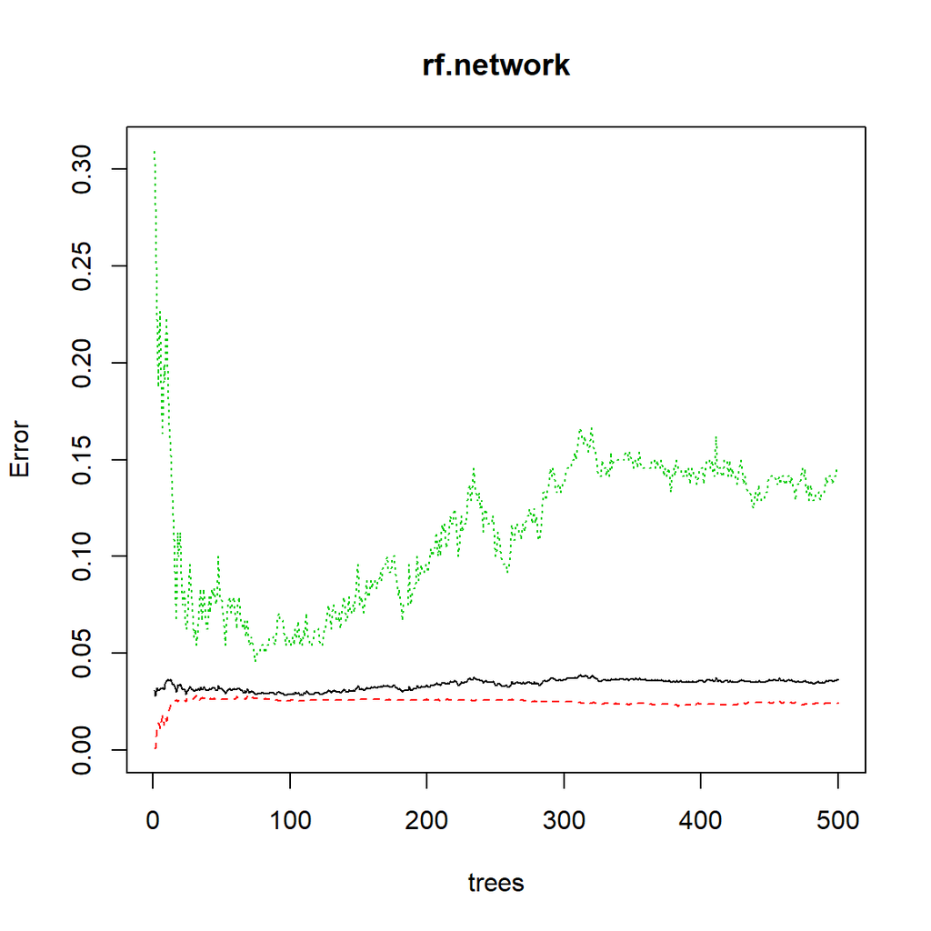

```r
plot(rf.network)
```

**Predictions and Confusion Matrix using Random Forest Model**

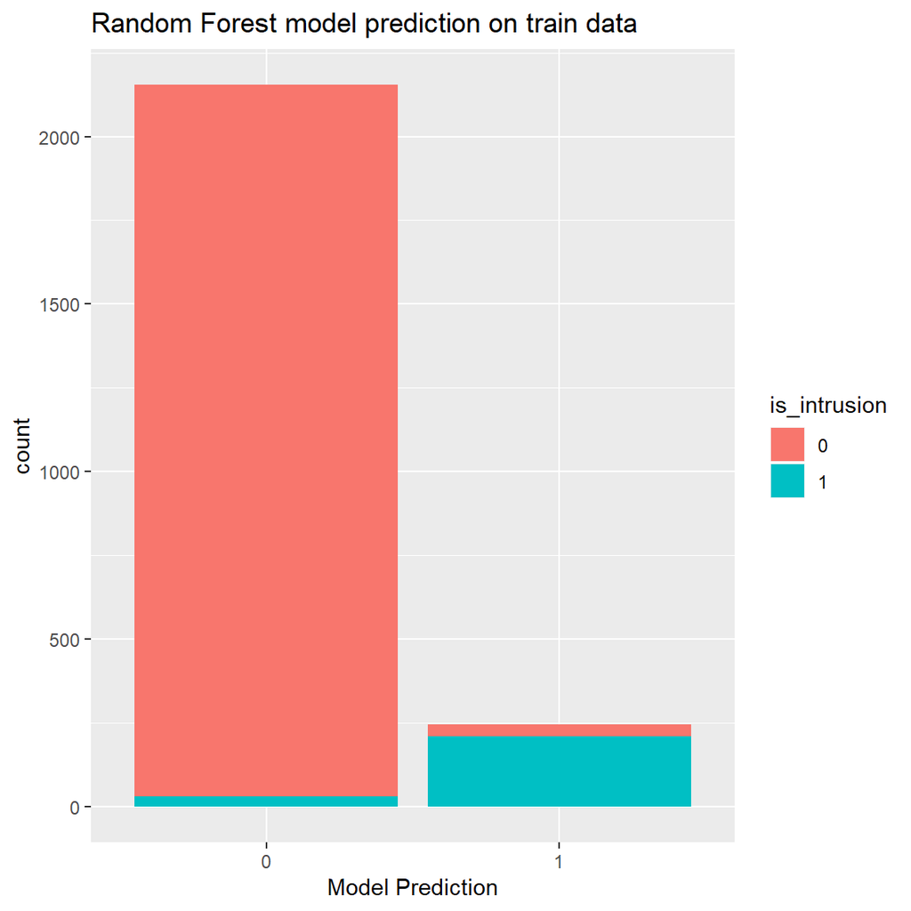

```r
pred.rf.train <- predict(rf.network, newdata = network.train,type = "class") #Predicting class for training data
rf.train.cm <- confusionMatrix(table(pred.rf.train, network.train$is_intrusion), positive = "1") #Confusion Matrix of training data predictions
ggplot(data = network.train, aes(x = pred.rf.train, fill = is_intrusion)) +geom_histogram(stat = "count") + labs(x = "Model Prediction", title = "Random Forest model prediction on train data")
```

```r
pred.rf.test <- predict(rf.network, newdata = network.test,type = "class") #Predicting class for test data
rf.test.cm <- confusionMatrix(table(pred.rf.test, network.test$is_intrusion), positive = "1")
rf.test.cm #Confusion Matrix of test data predictions
```

```
## Confusion Matrix and Statistics
##
##
## pred.rf.test   0   1
##            0 528   6
##            1  11  54
##
##                Accuracy : 0.9716
##                  95% CI : (0.9549, 0.9834)
##     No Information Rate : 0.8998
##     P-Value [Acc > NIR] : 1.069e-11
##
##                   Kappa : 0.8482
##
##  Mcnemar's Test P-Value : 0.332
##
##             Sensitivity : 0.90000
##             Specificity : 0.97959
##          Pos Pred Value : 0.83077
##          Neg Pred Value : 0.98876
##              Prevalence : 0.10017
##          Detection Rate : 0.09015
##    Detection Prevalence : 0.10851
##       Balanced Accuracy : 0.93980
##
##        'Positive' Class : 1
##
```